# song_recommender

## Project 2. Song recommendation system

#### Song recommendation

- Start with basic song data
- Test out multiple approaches - cosine similarity, KNN
- Try to incorporate lyrics data
- Try to incorporate more metadata
- Try to incorporate user playlist data / collaborative filtering / etc

#### Genre classification

- or key classification
- or song stat regression (as in how joyful is a song likely to be from an artist, in a key, with a bpm, from a year)

#### dataset information

```python
import pandas as pd
import numpy as np
import math
import sklearn
import plotly.express as px
import plotly
from plotly.subplots import make_subplots
import plotly.graph_objects as go
import matplotlib.pyplot as plt
import seaborn as sns

from sklearn.model_selection import train_test_split

from sklearn.preprocessing import StandardScaler
from sklearn.compose import ColumnTransformer
from sklearn.pipeline import Pipeline
```

```python
df = pd.read_csv('../datasets/spotify_songs.csv', index_col = 0)
# with engineered features, cleanup etc
df_eng = pd.read_csv('../datasets/spotify_songs_eng.csv', index_col = 0)
```

### Dataset exploration

```python
df.sample(5)
```

|  | track_id | artists | album_name | track_name | popularity | duration_ms | explicit | danceability | energy | key | loudness | mode | speechiness | acousticness | instrumentalness | liveness | valence | tempo | time_signature | track_genre |
| --- | --- | --- | --- | --- | --- | --- | --- | --- | --- | --- | --- | --- | --- | --- | --- | --- | --- | --- | --- | --- |
| 102999 | 4KROoGIaPaR1pBHPnR3bwC | Nick Drake | Pink Moon | Pink Moon | 69 | 124000 | False | 0.642 | 0.427 | 3 | -8.471 | 1 | 0.0402 | 0.8710 | 0.090400 | 0.1240 | 0.4040 | 82.344 | 4 | songwriter |
| 43321 | 6IfOFGLpJmYSyrKed5N3gk | Rogér Fakhr | Fine Anyway (Habibi Funk 016) | Fine Anyway | 52 | 163437 | False | 0.602 | 0.390 | 4 | -9.198 | 0 | 0.0408 | 0.8480 | 0.000250 | 0.1140 | 0.4840 | 62.470 | 4 | groove |
| 102285 | 21i2PhBdDKSlJ5gJZl2M7V | Chicago | Holly Jolly Christmas | (Because) It's Christmastime | 0 | 200026 | False | 0.711 | 0.742 | 11 | -5.434 | 0 | 0.0294 | 0.1720 | 0.000838 | 0.0502 | 0.7300 | 100.053 | 4 | songwriter |
| 17127 | 1d6BkMki9M6K0yp9OLBzOM | Actress | Karma & Desire | Fire and Light | 57 | 75969 | False | 0.337 | 0.280 | 0 | -18.646 | 0 | 0.0384 | 0.9870 | 0.882000 | 0.0851 | 0.0824 | 140.004 | 4 | club |
| 27330 | 1Jf5PyufpsLNeeMF32zHJ8 | SHY FX;T. Power | Diary of a Digital Soundboy | Sheets | 19 | 297533 | False | 0.356 | 0.902 | 9 | -2.658 | 0 | 0.0578 | 0.0228 | 0.060000 | 0.2940 | 0.4490 | 89.995 | 4 | drum-and-bass |

```python
df.describe()
```

|  | popularity | duration_ms | danceability | energy | key | loudness | mode | speechiness | acousticness | instrumentalness | liveness | valence | tempo | time_signature |
| --- | --- | --- | --- | --- | --- | --- | --- | --- | --- | --- | --- | --- | --- | --- |
| count | 114000.000000 | 1.140000e+05 | 114000.000000 | 114000.000000 | 114000.000000 | 114000.000000 | 114000.000000 | 114000.000000 | 114000.000000 | 114000.000000 | 114000.000000 | 114000.000000 | 114000.000000 | 114000.000000 |
| mean | 33.238535 | 2.280292e+05 | 0.566800 | 0.641383 | 5.309140 | -8.258960 | 0.637553 | 0.084652 | 0.314910 | 0.156050 | 0.213553 | 0.474068 | 122.147837 | 3.904035 |
| std | 22.305078 | 1.072977e+05 | 0.173542 | 0.251529 | 3.559987 | 5.029337 | 0.480709 | 0.105732 | 0.332523 | 0.309555 | 0.190378 | 0.259261 | 29.978197 | 0.432621 |
| min | 0.000000 | 0.000000e+00 | 0.000000 | 0.000000 | 0.000000 | -49.531000 | 0.000000 | 0.000000 | 0.000000 | 0.000000 | 0.000000 | 0.000000 | 0.000000 | 0.000000 |
| 25% | 17.000000 | 1.740660e+05 | 0.456000 | 0.472000 | 2.000000 | -10.013000 | 0.000000 | 0.035900 | 0.016900 | 0.000000 | 0.098000 | 0.260000 | 99.218750 | 4.000000 |
| 50% | 35.000000 | 2.129060e+05 | 0.580000 | 0.685000 | 5.000000 | -7.004000 | 1.000000 | 0.048900 | 0.169000 | 0.000042 | 0.132000 | 0.464000 | 122.017000 | 4.000000 |
| 75% | 50.000000 | 2.615060e+05 | 0.695000 | 0.854000 | 8.000000 | -5.003000 | 1.000000 | 0.084500 | 0.598000 | 0.049000 | 0.273000 | 0.683000 | 140.071000 | 4.000000 |
| max | 100.000000 | 5.237295e+06 | 0.985000 | 1.000000 | 11.000000 | 4.532000 | 1.000000 | 0.965000 | 0.996000 | 1.000000 | 1.000000 | 0.995000 | 243.372000 | 5.000000 |

```python
df.isnull().sum()
```

```
track_id            0
artists             1
album_name          1
track_name          1
popularity          0
duration_ms         0
explicit            0
danceability        0
energy              0
key                 0
loudness            0
mode                0
speechiness         0
acousticness        0
instrumentalness    0
liveness            0
valence             0
tempo               0
time_signature      0
track_genre         0
dtype: int64
```

1 or 2 rows with empty data, no problem with dropping them

```python
df = df.dropna()
```

```python
# df.to_csv('../datasets/spotify_songs_eng.csv')
```

```python
df.nunique()
```

```
track_id            89741
artists             31437
album_name          46589
track_name          73608
popularity            101
duration_ms         50697
explicit                2
danceability         1174
energy               2083
key                    12
loudness            19480
mode                    2
speechiness          1489
acousticness         5061
instrumentalness     5346
liveness             1722
valence              1790
tempo               45653
time_signature          5
track_genre           114
dtype: int64
```

#### finding duplicates - new dataset variable 'df_eng'

```python
duplicated = df.duplicated(subset=['track_id'])
```

```python
duplicated
```

```
0         False
1         False
2         False
3         False
4         False
          ...
113995    False
113996    False
113997    False
113998    False
113999    False
Length: 113999, dtype: bool
```

```python
dup_df = df[duplicated].sort_values(by=['track_id'])
```

```python
dup_df.head()
```

|  | track_id | artists | album_name | track_name | popularity | duration_ms | explicit | danceability | energy | key | loudness | mode | speechiness | acousticness | instrumentalness | liveness | valence | tempo | time_signature | track_genre |
| --- | --- | --- | --- | --- | --- | --- | --- | --- | --- | --- | --- | --- | --- | --- | --- | --- | --- | --- | --- | --- |
| 103211 | 001APMDOl3qtx1526T11n1 | Pink Sweat$;Kirby | New RnB | Better | 0 | 176320 | False | 0.613 | 0.471 | 1 | -6.644 | 0 | 0.1070 | 0.31600 | 0.000001 | 0.1170 | 0.406 | 143.064 | 4 | soul |
| 100420 | 001YQlnDSduXd5LgBd66gT | Soda Stereo | Soda Stereo (Remastered) | El Tiempo Es Dinero - Remasterizado 2007 | 38 | 177266 | False | 0.554 | 0.921 | 2 | -4.589 | 1 | 0.0758 | 0.01940 | 0.088100 | 0.3290 | 0.700 | 183.571 | 1 | ska |
| 91801 | 003vvx7Niy0yvhvHt4a68B | The Killers | Hot Fuss | Mr. Brightside | 86 | 222973 | False | 0.352 | 0.911 | 1 | -5.230 | 1 | 0.0747 | 0.00121 | 0.000000 | 0.0995 | 0.236 | 148.033 | 4 | rock |
| 3257 | 003vvx7Niy0yvhvHt4a68B | The Killers | Hot Fuss | Mr. Brightside | 86 | 222973 | False | 0.352 | 0.911 | 1 | -5.230 | 1 | 0.0747 | 0.00121 | 0.000000 | 0.0995 | 0.236 | 148.033 | 4 | alternative |
| 94239 | 004h8smbIoAkUNDJvVKwkG | Ouse;Powfu | Loners Diary | Lovemark | 58 | 219482 | True | 0.808 | 0.331 | 5 | -13.457 | 1 | 0.0557 | 0.13100 | 0.000000 | 0.2250 | 0.337 | 140.035 | 4 | sad |

```python
df_eng = df.drop_duplicates(subset=['track_id'], keep='first')
```

```python
df_eng = df_eng.reset_index()
```

#### data distributions

```python
df_eng.dtypes
```

```
track_id             object
artists              object
album_name           object
track_name           object
popularity            int64
duration_ms           int64
explicit               bool
danceability        float64
energy              float64
key                   int64
loudness            float64
mode                  int64
speechiness         float64
acousticness        float64
instrumentalness    float64
liveness            float64
valence             float64
tempo               float64
time_signature        int64
track_genre          object
dtype: object
```

#### True / False to int

```python
df_eng['explicit'] = df_eng['explicit'].astype(int)
```

#### Selecting numerical columns

```python
cols_no_index = [col for col in df_eng.columns if col != 'index']
cols_no_index
```

```
['track_id',
 'artists',
 'album_name',
 'track_name',
 'popularity',
 'duration_ms',
 'explicit',
 'danceability',
 'energy',
 'key',
 'loudness',
 'mode',
 'speechiness',
 'acousticness',
 'instrumentalness',
 'liveness',
 'valence',
 'tempo',
 'time_signature',
 'track_genre']
```

```python
numerical_cols = [col for col in cols_no_index if df[col].dtype in ['int64', 'float64', 'int32']]
numerical_cols
```

```
['popularity',
 'duration_ms',
 'danceability',
 'energy',
 'key',
 'loudness',
 'mode',
 'speechiness',
 'acousticness',
 'instrumentalness',
 'liveness',
 'valence',
 'tempo',
 'time_signature']
```

```python
len(numerical_cols)
```

```
14
```

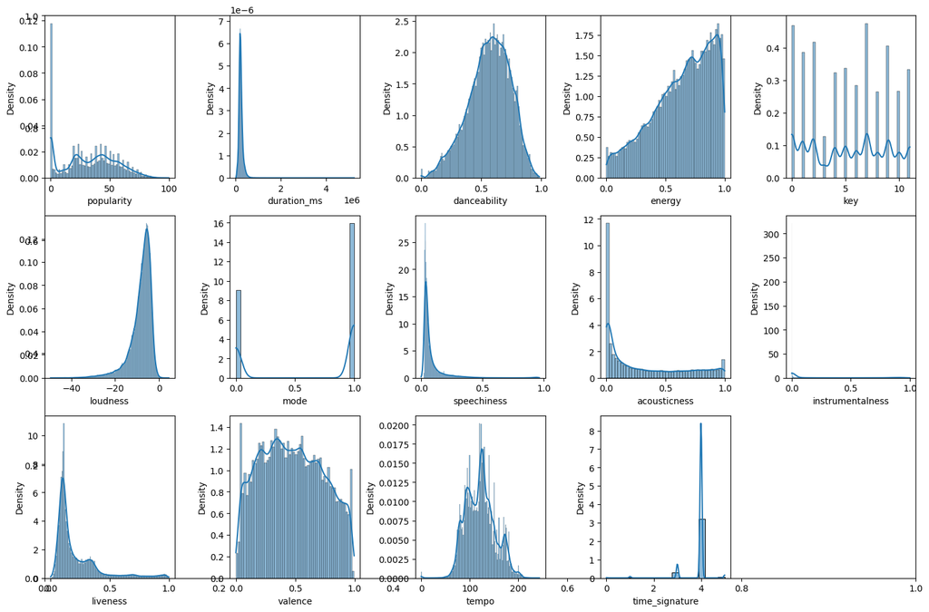

```python
plt.subplots(figsize = (15,10))
for i, col in enumerate(numerical_cols):
    plt.subplot(3,5, i+1)
    sns.histplot(df_eng[col], kde=True, stat="density")
    # sns.histplot(df_eng[col], kde=True)
plt.tight_layout()
plt.show()
```

#### Some distribution notes

- Should songs with instrumentalness, acousticness or speechiness of 0 be removed? They could legitimately have those statistics
- Other than the mentioned 0s no significant outliers seem to be present, maybe some in the duration_ms section

```python
df_eng['duration_ms'].sort_values(ascending=False).head(5)
```

```
61360    5237295
10201    4789026
22992    4730302
61582    4563897
12508    4447520
Name: duration_ms, dtype: int64
```

```python
df_eng[df_eng['duration_ms'] > 4000000]
```

|  | index | track_id | artists | album_name | track_name | popularity | duration_ms | explicit | danceability | energy | ... | loudness | mode | speechiness | acousticness | instrumentalness | liveness | valence | tempo | time_signature | track_genre |
| --- | --- | --- | --- | --- | --- | --- | --- | --- | --- | --- | --- | --- | --- | --- | --- | --- | --- | --- | --- | --- | --- |
| 10201 | 10935 | 0LBIf9EFHuxmuNig4JHGZo | Timo Maas | Crossing Wires 002 - Compiled And Mixed By Tim... | Crossing Wires 002 - Continuous DJ Mix | 11 | 4789026 | 0 | 0.6970 | 0.632 | ... | -12.469 | 1 | 0.0451 | 0.00815 | 0.8710 | 0.0998 | 0.15100 | 121.055 | 4 | breakbeat |
| 12359 | 13195 | 3se0UYprtkHthJEBuk1A5K | Mark Farina | Greenhouse Construction | Greenhouse Construction | 12 | 4334721 | 0 | 0.8460 | 0.744 | ... | -9.260 | 0 | 0.0611 | 0.00371 | 0.3350 | 0.3130 | 0.53200 | 125.434 | 4 | chicago-house |
| 12409 | 13245 | 13hQAhg1owjTpTcI9xQc6c | Mark Farina | Live In Tokyo | Live In Tokyo - Continuous Mix | 11 | 4339826 | 0 | 0.8060 | 0.582 | ... | -12.181 | 1 | 0.0874 | 0.00830 | 0.2370 | 0.3280 | 0.68600 | 128.368 | 4 | chicago-house |
| 12508 | 13344 | 3gFme8BdfTtFHxKmuTnSbj | Mark Farina | House of OM (DJ Mix) | House of Om - Mark Farina - Continuous Mix | 11 | 4447520 | 0 | 0.8610 | 0.805 | ... | -6.461 | 0 | 0.0711 | 0.00548 | 0.5770 | 0.1350 | 0.54500 | 129.306 | 4 | chicago-house |
| 22992 | 24348 | 6wypxnAvmv5zYewUX3VFDd | Seth Troxler | Seth Troxler - The Lab 03 | The Lab 03 - Continuous DJ Mix Part 1 | 8 | 4730302 | 0 | 0.6840 | 0.656 | ... | -11.163 | 0 | 0.0633 | 0.01910 | 0.8480 | 0.1030 | 0.30100 | 123.180 | 4 | detroit-techno |
| 26429 | 27926 | 6eTDnsdPlRUyrTHqFj3l7W | Lenzman;Dan Stezo | NQ State of Mind | NQ State of Mind, Vol. 1 - Continuous DJ Mix | 15 | 4246206 | 1 | 0.5930 | 0.924 | ... | -3.979 | 1 | 0.0899 | 0.00369 | 0.0221 | 0.5340 | 0.24200 | 173.938 | 4 | drum-and-bass |
| 61360 | 73617 | 3Cnz3Bu9Wcw8p3kiBTXTxp | Tale Of Us | Unity (Voyage Mix) | Unity (Voyage Mix) Pt. 1 | 35 | 5237295 | 0 | 0.6950 | 0.736 | ... | -11.371 | 0 | 0.0374 | 0.00399 | 0.8600 | 0.0910 | 0.05090 | 124.001 | 4 | minimal-techno |
| 61582 | 73840 | 6JbQr97EMFD2D3Ek6gxgt1 | Loco Dice | Amnesia Ibiza - Underground 10 | Amnesia Ibiza Underground 10 DJ Mix | 17 | 4563897 | 0 | 0.7830 | 0.728 | ... | -10.176 | 0 | 0.0612 | 0.00158 | 0.8400 | 0.1580 | 0.18900 | 125.044 | 4 | minimal-techno |
| 80325 | 101390 | 2QfFLpSGF1T1pY6tq4kD7Z | Ocean Sounds | Ocean Waves Sounds to Relax and Sleep | Ocean Waves Sounds | 39 | 4120258 | 0 | 0.0797 | 0.995 | ... | -17.379 | 1 | 0.0612 | 0.93200 | 0.5620 | 0.3100 | 0.00001 | 84.788 | 3 | sleep |

9 rows × 21 columns

Tracks like 'continuous mix' do appear like legitimate entrances. They shall be considered in later tasks. In case of a recommendation system considering the song durations as a feature, due to how extreme their duraton values are, they are likely to only be considered together.

### Similarity finding

#### Using KNN and euclidean distance

#### Querying functions

- knnQuery - find k most similar songs
- rangeQuery - find songs within radius of similarity from the query point, with the query point defined by the index of the song

```python
# K-query
def knnQuery(queryPoint, arrCharactPoints, k):
    """
    Calculates the distance of supplied song index
    ---
    Arguments:
        queryPoint - chosen song index from the df_eng dataframe
        arrCharactPoints - index to consider for distance calculation
        k - the number of closest songs to return
    Returns:
        np array of song indexes
    """
    tmp = arrCharactPoints.copy(deep=True)
    tmp['dist'] = tmp.apply(lambda x: np.linalg.norm(x-queryPoint), axis=1)
    tmp = tmp.sort_values('dist')
    return tmp.head(k).index

# K-query
# with distances included
def knnQueryFull(queryPoint, arrCharactPoints, k):
    """
    Calculates the distance of supplied song index
    ---
    Arguments:
        queryPoint - chosen song index from the df_eng dataframe
        arrCharactPoints - index to consider for distance calculation
        k - the number of closest songs to return
    Returns:
        list of tuples of structure [ (song_index, distance), (index, distance), ...] of len k
    """
    tmp = arrCharactPoints.copy(deep=True)
    tmp['dist'] = tmp.apply(lambda x: np.linalg.norm(x-queryPoint), axis=1)
    tmp = tmp.sort_values('dist')
    return_idx = list(tmp.head(k).index)
    return_dist = tmp.head(k)['dist'].values
    return_list = [(index, dist) for index, dist in zip(return_idx, return_dist)]
    return return_list

# Range query
def rangeQuery(queryPoint, arrCharactPoints, radius):
    tmp = arrCharactPoints.copy(deep=True)
    tmp['dist'] = tmp.apply(lambda x: np.linalg.norm(x-queryPoint), axis=1)
    tmp['radius'] = tmp.apply(lambda x: 1 if x['dist'] <= radius else 0, axis=1)
    return tmp.query('radius == 1').index
```

#### Function to execute the chosen query with the chosen song index, returns songs satisfying the chosen query condition

```python
# Execute k-NN removing the 'query point'
def querySimilars(df, columns, idx, func, param):
    """
    Executes the supplied func query by removing the input song by index (idx),
    considering only the selected df columns, with param being k or range threshold
    response = func(queryPoint, arr, param)
    returns response based on supplied func function
    """
    arr = df[columns].copy(deep=True)
    queryPoint = arr.loc[idx]
    arr = arr.drop([idx])
    response = func(queryPoint, arr, param)
    return response
```

### Function to sample n random songs and their indexes

```python
def sample_n_songs(df, n):
    sample_songs = df.sample(n)
    sample_songs_names = sample_songs['track_name'].values
    sample_songs_idx = list(sample_songs.index)
    return sample_songs, sample_songs_names, sample_songs_idx
```

```python
sample_songs, sample_songs_names, sample_songs_idx = sample_n_songs(df_eng, 10)
```

```python
sample_songs_idx
```

```
[4346, 25389, 68888, 32939, 9523, 9258, 39003, 74140, 94175, 86998]
```

```python
sample_songs
```

|  | track_id | artists | album_name | track_name | popularity | duration_ms | explicit | danceability | energy | key | loudness | mode | speechiness | acousticness | instrumentalness | liveness | valence | tempo | time_signature | track_genre |
| --- | --- | --- | --- | --- | --- | --- | --- | --- | --- | --- | --- | --- | --- | --- | --- | --- | --- | --- | --- | --- |
| 4346 | 1vTkNAelvP5V2vbQ5rAbu3 | Max Richter;Elena Urioste;Chineke! Orchestra | Antonio Vivaldi - Inspiring Classics | Recomposed By Max Richter: Vivaldi, The Four S... | 11 | 92087 | 0 | 0.327 | 0.4050 | 5 | -13.561 | 1 | 0.0538 | 0.8390 | 0.96500 | 0.0744 | 0.478 | 165.180 | 3 | ambient |
| 25389 | 6uopsC7wCZfSZc4TfyjazT | Almklausi | Ballermann Party Mix - Alle Après Ski Hütten H... | Eine Skifahrt die ist lustig | 0 | 190014 | 0 | 0.696 | 0.9890 | 11 | -3.711 | 1 | 0.1300 | 0.0421 | 0.00000 | 0.4130 | 0.516 | 141.039 | 4 | disco |
| 68888 | 06aqptFP9n0y4pPTQOEWKr | Vuelta Canela | Juegos Canelos | Una Nube | 41 | 157219 | 0 | 0.705 | 0.0715 | 0 | -23.231 | 1 | 0.6420 | 0.7940 | 0.00000 | 0.7770 | 0.713 | 115.326 | 4 | latino |
| 32939 | 4PuvBMm0y4klls9NCg8lxl | HXE | Drop That MF | Drop That MF | 33 | 116006 | 1 | 0.947 | 0.1930 | 7 | -12.119 | 1 | 0.4820 | 0.0181 | 0.36800 | 0.1110 | 0.135 | 129.985 | 4 | electronic |
| 9523 | 3vddabBsXcvoerPkIlDHDF | Central 3;André Aquino | Tudo a Ver Com Ele (Ao Vivo) | Tudo a Ver Com Ele - Ao Vivo | 46 | 429127 | 0 | 0.372 | 0.6580 | 7 | -6.531 | 1 | 0.0404 | 0.3290 | 0.00000 | 0.6880 | 0.212 | 136.975 | 4 | brazil |
| 9258 | 1ACPXBpp4m1okYEiUkYfcU | Colo de Deus | O Cordeiro, o Leão e o Trono - Parte 1 (Ao Vivo) | Desperta - Ao Vivo | 47 | 460040 | 0 | 0.400 | 0.6850 | 1 | -6.752 | 0 | 0.0566 | 0.6960 | 0.00000 | 0.7020 | 0.147 | 138.941 | 4 | brazil |
| 39003 | 5jyPgh9K0YlyhlVGQzFsbO | Robin Schulz;David Guetta | House Anthems | On Repeat | 5 | 190217 | 0 | 0.609 | 0.8010 | 1 | -8.483 | 0 | 0.0694 | 0.0246 | 0.00255 | 0.3700 | 0.202 | 122.958 | 4 | german |
| 74140 | 5J46ZclMEseJiZklYTs1fB | Milton Nascimento;Chico Buarque | Fiesta temática 70s | O Que Será (A Flor Da Pele) | 0 | 247426 | 0 | 0.431 | 0.3660 | 4 | -12.371 | 0 | 0.0354 | 0.6890 | 0.00000 | 0.4340 | 0.258 | 112.096 | 4 | mpb |
| 94175 | 5KPSKv02jtAsI7fmpT7enC | me7k | Is It Too Much to Ask For | Is It Too Much to Ask For | 62 | 100586 | 0 | 0.901 | 0.4670 | 10 | -9.142 | 1 | 0.0586 | 0.0500 | 0.01530 | 0.1050 | 0.580 | 105.586 | 4 | sad |
| 86998 | 6zpBjeIne0jS2AVCElureG | Kapelle Petra | Nackt | Also stoßen wir an | 37 | 235152 | 0 | 0.409 | 0.8130 | 3 | -4.346 | 1 | 0.0376 | 0.0138 | 0.00000 | 0.1830 | 0.480 | 188.115 | 4 | punk |

#### Querying by number of songs

```python
# Selecting query parameters
func, param = knnQuery, 5 # k=5

# Querying
response = querySimilars(df_eng, numerical_cols, sample_songs_idx[0], func, param)

print("Querying:")
print(sample_songs_idx[0], df_eng.loc[sample_songs_idx[0]]['track_name'])
print("Similar songs:")
for idx in response:
    track_name = df_eng.loc[idx]['track_name']
    print(idx, track_name)
```

[output not shown]

Querying by range threshold  
Doesn't seem to be working

```python
# Selecting query parameters
func, param = rangeQuery, 0.5 # threshold distance
# Querying
response = querySimilars(df_eng, numerical_cols, sample_songs_idx[1], func, param)

print("Querying:")
print(sample_songs_idx[1], df_eng.loc[sample_songs_idx[1]]['track_name'])
print("Similar songs:")
for idx in response:
    track_name = df_eng.loc[idx]['track_name']
    print(idx, track_name)
```

[output not shown]

#### Function to knn query by song index and return similar song indexes

```python
def query_by_song(song_idx, df, columns, k, type='knn'):
    """
    Utilizes knnQuery, knnQueryFull and querySimilars to query similar songs by input song index,
    calculating the distance by selected columns
    returns a dataframe with the queried song and k similar songs, marking the query song with 'is_query' = 1
    ---
    Arguments:
        song_idx - query song index
        df - source dataframe
        columns - selected columns
        k - how many songs to return in the result dataframe
    """
    # Selecting query parameters
    if type == 'knn':
        func, param = knnQueryFull, k
    if type == 'cosine':
        func, param = cosineQueryFull, k
    if type == 'cosine_text':
        func, param = cosineQueryWithTextFull, k
    # Querying
    response = querySimilars(df, columns, song_idx, func, param)

    print("Querying:")
    print(song_idx, df.loc[song_idx]['track_name'])
    # print("Query song stats:")
    # print(df.loc[song_idx])
    # print("Similar songs:")

    input_song = df.loc[song_idx]
    similar_songs = pd.DataFrame(input_song).T
    similar_songs['dist'] = 0
    similar_songs['is_query'] = 1
    similar_songs

    for resp in response:
        idx = resp[0]
        dist = resp[1]
        track_name = df.loc[idx]['track_name']
        track = df.loc[idx]
        track_df = pd.DataFrame(track).T
        track_df['dist'] = dist
        track_df['is_query'] = 0
        similar_songs = pd.concat([similar_songs, track_df])
        print(f'idx: {idx}, track: {track_name}, dist: {dist}')

    return similar_songs
```

```python
# dft1 = pd.DataFrame(df_eng.loc[25671]).T
```

```python
# dft2 = pd.DataFrame(df_eng.loc[25672]).T
```

```python
# dft1 = pd.concat([dft1, dft2])
```

```python
# dft1
```

```python
test_song_idx = df_eng.sample(1).index.values[0]
test_song_idx
```

```
75034
```

```python
test_similar_songs = query_by_song(test_song_idx, df_eng, numerical_cols, 10)
```

```
Querying:
75034 Believe - From "The Polar Express"
idx: 79189, track: Believe - From "The Polar Express", dist: 0.0
idx: 23347, track: Breeze, dist: 44.20502406062008
idx: 27680, track: Hail Up The Lion, dist: 46.96126996122121
idx: 10276, track: Hail Up The Lion, dist: 46.96126996122121
idx: 61279, track: 夕陽1/3, dist: 49.238059649421615
idx: 46191, track: Forever Young - Paul Says MERRY XMESS Bootleg, dist: 65.44413250849864
idx: 54855, track: Headwind, dist: 65.46698616860257
idx: 50468, track: Minä olen, dist: 66.28990266986615
idx: 17805, track: Fuschia, dist: 68.01429255744709
idx: 111620, track: Fixed Income, dist: 69.87915813388138
```

```python
test_similar_songs
```

|  | track_id | artists | album_name | track_name | popularity | duration_ms | explicit | danceability | energy | key | ... | speechiness | acousticness | instrumentalness | liveness | valence | tempo | time_signature | track_genre | dist | is_query |
| --- | --- | --- | --- | --- | --- | --- | --- | --- | --- | --- | --- | --- | --- | --- | --- | --- | --- | --- | --- | --- | --- |
| 75034 | 1tTjmC6FSSFE04FkNpa3xJ | Jim Brickman | Christmas Faves 2022 | Believe - From "The Polar Express" | 0 | 289053 | 0 | 0.364 | 0.11 | 4 | ... | 0.0771 | 0.985 | 0.924 | 0.111 | 0.15 | 196.58 | 3 | new-age | 0.000000 | 1 |
| 79189 | 1tTjmC6FSSFE04FkNpa3xJ | Jim Brickman | Christmas Faves 2022 | Believe - From "The Polar Express" | 0 | 289053 | 0 | 0.364 | 0.11 | 4 | ... | 0.0771 | 0.985 | 0.924 | 0.111 | 0.15 | 196.58 | 3 | piano | 0.000000 | 0 |
| 23347 | 6oTwOCKqIGCSHsO5KJit9V | Axero | Energetic Takeoff EDM | Breeze | 0 | 289090 | 0 | 0.514 | 0.802 | 9 | ... | 0.0313 | 0.0416 | 0.522 | 0.106 | 0.295 | 176.088 | 4 | deep-house | 44.205024 | 0 |
| 27680 | 3RDWPnDrE0GTOaYTqpeX3X | Ed Solo;Deekline | No No No | Hail Up The Lion | 16 | 289090 | 0 | 0.634 | 0.891 | 7 | ... | 0.0522 | 0.000197 | 0.000167 | 0.182 | 0.537 | 176.02 | 4 | drum-and-bass | 46.961270 | 0 |
| 10276 | 3RDWPnDrE0GTOaYTqpeX3X | Ed Solo;Deekline | No No No | Hail Up The Lion | 16 | 289090 | 0 | 0.634 | 0.891 | 7 | ... | 0.0522 | 0.000197 | 0.000167 | 0.182 | 0.537 | 176.02 | 4 | breakbeat | 46.961270 | 0 |
| 61279 | 3L5vwQmbLivfbimSTkx5fG | Keyakizaka46 | 真っ白なものは汚したくなる (Complete Edition) | 夕陽1/3 | 25 | 289066 | 0 | 0.416 | 0.867 | 6 | ... | 0.0423 | 0.115 | 0.0 | 0.338 | 0.822 | 158.989 | 4 | j-idol | 49.238060 | 0 |
| 46191 | 5dCXXvJg4sJBPErwZiWhCW | Paul Elstak | b2s Presents Paul Elstak | Forever Young - Paul Says MERRY XMESS Bootleg | 24 | 289106 | 0 | 0.414 | 0.979 | 7 | ... | 0.152 | 0.025 | 0.000003 | 0.299 | 0.0765 | 169.976 | 4 | happy | 65.444133 | 0 |
| 54855 | 4anysyWdzzghWjZxDeXbce | Lusine | Language Barrier | Headwind | 11 | 289106 | 0 | 0.41 | 0.526 | 7 | ... | 0.0371 | 0.049 | 0.944 | 0.281 | 0.227 | 160.005 | 4 | idm | 65.466986 | 0 |
| 50468 | 7lltIP2aLYnEwbrKdYq0gb | Kotiteollisuus | Helvetistä itään | Minä olen | 23 | 289013 | 0 | 0.425 | 0.947 | 4 | ... | 0.0483 | 0.000018 | 0.883 | 0.331 | 0.376 | 151.009 | 4 | heavy-metal | 66.289903 | 0 |
| 17805 | 1G950qfSStXZLjScolxmmv | Dark0 | Solace | Fuschia | 16 | 289018 | 0 | 0.786 | 0.461 | 7 | ... | 0.0841 | 0.0597 | 0.941 | 0.138 | 0.252 | 142.04 | 4 | club | 68.014293 | 0 |
| 111620 | 3gFcTurpWAHpNOEMQGxBS0 | DJ Shadow | The Private Press | Fixed Income | 19 | 289000 | 0 | 0.611 | 0.722 | 9 | ... | 0.0333 | 0.0835 | 0.916 | 0.0969 | 0.615 | 156.476 | 4 | trip-hop | 69.879158 | 0 |

11 rows × 22 columns

```python
test_similar_songs['dist'].mean()
```

```
47.49637233370727
```

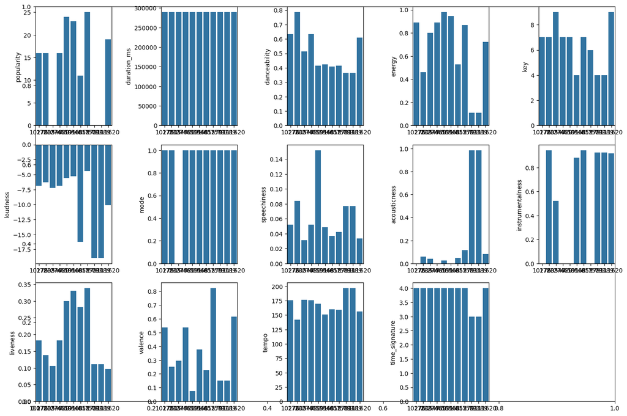

```python
plt.subplots(figsize = (15,10))
for i, col in enumerate(numerical_cols):
    plt.subplot(3,5, i+1)
    # sns.histplot(df_eng[col], kde=True, stat="density")
    # sns.histplot(df_eng[col], kde=True)
    sns.barplot(test_similar_songs[col])
plt.tight_layout()
plt.show()
```

Interestlingly, we got songs from many genres, with one repeated artist, with a wide range of song charactristics, with the only uniformity in song duration

#### Testing for more songs

To see if some more relations / distributions can be noticed, particularly in terms of calculated song distance and its relation with other stats, depending on the input song

```python
sample_songs, sample_songs_names, sample_songs_idx = sample_n_songs(df_eng, 10)
results_10_df = pd.DataFrame()
for song_idx in sample_songs_idx:
    song_results = query_by_song(song_idx, df_eng, numerical_cols, 10)
    results_10_df = pd.concat([results_10_df, song_results])
results_10_df = results_10_df.reset_index(drop=True)
```

```
Querying:
51282 Satisfy
idx: 8823, track: Joker And The Thief, dist: 18.658243196239024
idx: 38242, track: Joker And The Thief, dist: 18.658243196239024
idx: 84379, track: Joker And The Thief, dist: 18.658243196239024
idx: 113355, track: Here For You - Live, dist: 22.716755677913167
idx: 2202, track: Boku no Sensou, dist: 28.546880627935504
idx: 3355, track: Boku no Sensou, dist: 28.546880627935504
idx: 63009, track: Boku no Sensou, dist: 28.546880627935504
idx: 74815, track: Janaina, dist: 33.349351271823096
idx: 41188, track: Glory, Amen, dist: 40.531586366191
idx: 9304, track: Luz em Todo Morro - Acústico, dist: 49.21423473161907
Querying:
77364 Fica / Tudo Fica Blue - Ao Vivo
idx: 40949, track: A Oferta da Viuvinha, dist: 13.22582660290086
idx: 46850, track: See You Again - Radio Edit, dist: 14.008142995204627
idx: 32255, track: Sauce, dist: 18.182546438824616
idx: 38312, track: Looking For Something, dist: 22.531344014061837
idx: 100539, track: Se Va, dist: 23.184433142520426
idx: 9378, track: Fé Menina, dist: 28.53586047852771
idx: 88936, track: Fé Menina, dist: 28.53586047852771
idx: 21291, track: Si Tú Me Quisieras, dist: 29.66290563110767
idx: 31550, track: talk is overrated, dist: 32.17783040557584
idx: 26428, track: De muziek gaat altijd door, dist: 37.132381423226825
Querying:
109837 Bánat utca
idx: 73293, track: Bánat utca, dist: 1.0
idx: 1878, track: Constante Mesmice, dist: 11.692508256144189
idx: 10117, track: We Want Your Soul, dist: 12.209793183554847
idx: 73098, track: So Far So Good - Frankov Remix 2022, dist: 25.515354646337958
idx: 109247, track: So Far So Good - Frankov Remix 2022, dist: 25.515354646337958
idx: 23547, track: So Far So Good - Frankov Remix 2022, dist: 25.515354646337958
idx: 113132, track: In Control, dist: 34.42935052683974
idx: 74402, track: Cigano (Ao Vivo), dist: 38.178442977939056
idx: 13348, track: Right Thing, dist: 38.61267810732475
idx: 34824, track: Tujhe Main Pyar Karu (From "1920"), dist: 39.30687131978327
Querying:
3647 A feira
idx: 9047, track: A feira, dist: 0.0
idx: 87095, track: A feira, dist: 0.0
```

[output cut: 65 more lines]

```
idx: 104258, track: Rumba, dist: 105.23148758957653
idx: 66498, track: Dede 3x, dist: 105.6265473263611
idx: 15559, track: be someone to never lose, dist: 106.58772066896182
Querying:
30644 Don't You Wanna Play?
idx: 31897, track: Don't You Wanna Play?, dist: 0.0
idx: 53644, track: Don't You Wanna Play?, dist: 0.0
idx: 26646, track: Dyscyplina, dist: 33.40440337320814
idx: 105941, track: Burnt Toast, dist: 33.457914636151486
idx: 104843, track: Prólogo, dist: 38.0727570079972
idx: 74689, track: Tá Bom, dist: 42.37902864580804
idx: 87872, track: Tá Bom, dist: 42.37902864580804
idx: 59785, track: Listreaux Grackle Inc. (feat. Buddy Mv), dist: 44.74898084928862
idx: 19375, track: Holly Jolly Christmas, dist: 45.88275617179108
idx: 108041, track: Malena (with Orquesta Tipica Porteña), dist: 51.66431883737574
```

```python
results_10_df.sample(5)
```

|  | track_id | artists | album_name | track_name | popularity | duration_ms | explicit | danceability | energy | key | ... | speechiness | acousticness | instrumentalness | liveness | valence | tempo | time_signature | track_genre | dist | is_query |
| --- | --- | --- | --- | --- | --- | --- | --- | --- | --- | --- | --- | --- | --- | --- | --- | --- | --- | --- | --- | --- | --- |
| 63 | 1vn1f7DF7e4dbnAmdxeg5m | Raul Seixas | Caminhos | Eu Nasci Há 10 Mil Anos Atrás | 40 | 289173 | 0 | 0.486 | 0.825 | 9 | ... | 0.147 | 0.326 | 0.0 | 0.369 | 0.829 | 135.736 | 4 | mpb | 33.107737 | 0 |
| 8 | 3FOaym5lHj9N5QcDIgQXQ0 | Otto | Certa Manha Acordei De Sonhos Intranquilos | Janaina | 39 | 280440 | 0 | 0.499 | 0.705 | 7 | ... | 0.0548 | 0.355 | 0.000107 | 0.135 | 0.881 | 172.355 | 4 | mpb | 33.349351 | 0 |
| 24 | 6SRpVxkMTYbFSrTt9b7Kri | Nomade Orquestra;Edgar | Vox Populi, Vol. 1 | Constante Mesmice | 16 | 307493 | 0 | 0.743 | 0.643 | 9 | ... | 0.0434 | 0.0462 | 0.0775 | 0.0694 | 0.591 | 128.029 | 4 | afrobeat | 11.692508 | 0 |
| 78 | 2k7lStJS8TJvMNxbdClLMD | Aqua Timez | うたい去りし花 | Velonica | 56 | 278400 | 0 | 0.495 | 0.925 | 7 | ... | 0.0417 | 0.000129 | 0.0 | 0.139 | 0.587 | 136.977 | 4 | j-rock | 0.000000 | 0 |
| 7 | 3KhwEuqLNjHfsKaBDo1yVh | Shinsei Kamattechan | Boku no Sensou | Boku no Sensou | 66 | 280466 | 0 | 0.473 | 0.936 | 2 | ... | 0.0704 | 0.00916 | 0.0422 | 0.31 | 0.416 | 144.014 | 4 | j-rock | 28.546881 | 0 |

5 rows × 22 columns

```python
results_10_df[results_10_df['is_query'] == 1]
```

|  | track_id | artists | album_name | track_name | popularity | duration_ms | explicit | danceability | energy | key | ... | speechiness | acousticness | instrumentalness | liveness | valence | tempo | time_signature | track_genre | dist | is_query |
| --- | --- | --- | --- | --- | --- | --- | --- | --- | --- | --- | --- | --- | --- | --- | --- | --- | --- | --- | --- | --- | --- |
| 0 | 2SazZ5d4m9G5IWu5xdMjZf | Sidhu Moose Wala;Shooter Kahlon | Satisfy | Satisfy | 62 | 280464 | 0 | 0.683 | 0.8 | 5 | ... | 0.168 | 0.431 | 0.0 | 0.357 | 0.748 | 172.024 | 4 | hip-hop | 0.0 | 1 |
| 11 | 6QlxhWfDUd1X2MfpBphBke | Mumuzinho;Ferrugem | Resenha Do Mumu (Ao Vivo) | Fica / Tudo Fica Blue - Ao Vivo | 46 | 189801 | 0 | 0.505 | 0.716 | 4 | ... | 0.0768 | 0.496 | 0.0 | 0.544 | 0.811 | 163.937 | 4 | pagode | 0.0 | 1 |
| 22 | 1VIzgYvo4Got947F1EMGIo | Zareh Kan;Sunshine State;Goldsound | Bánat utca | Bánat utca | 25 | 307500 | 0 | 0.907 | 0.727 | 7 | ... | 0.0617 | 0.0015 | 0.113 | 0.0697 | 0.239 | 128.001 | 4 | techno | 0.0 | 1 |
| 33 | 27sytaeEm6TDVMpdExyVfd | O Rappa | Só as Melhores do Pop Rock Brasileiro | A feira | 0 | 239533 | 0 | 0.713 | 0.886 | 7 | ... | 0.0411 | 0.0012 | 0.000008 | 0.0496 | 0.9 | 97.983 | 4 | alternative | 0.0 | 1 |
| 44 | 6LBsmn8XJRNXv1jBBWFHV1 | Kenny Rogers | Merry Christmas | I'll Be Home for Christmas | 0 | 164906 | 0 | 0.437 | 0.229 | 9 | ... | 0.0296 | 0.729 | 0.000091 | 0.129 | 0.127 | 61.786 | 4 | country | 0.0 | 1 |
| 55 | 57CZLRVyGf21PgF573ZkPn | Capital Inicial | Capital Inicial Multishow Ao Vivo | Não Olhe Pra Trás - Ao Vivo | 40 | 289173 | 0 | 0.484 | 0.882 | 7 | ... | 0.0388 | 0.0444 | 0.00075 | 0.974 | 0.298 | 102.981 | 4 | mpb | 0.0 | 1 |
| 66 | 4NJgTHFLJKCu1Y4XVwlHKw | Kelly Lee Owens | Let It Go / Omen | Omen | 18 | 242079 | 0 | 0.795 | 0.528 | 0 | ... | 0.0617 | 0.757 | 0.964 | 0.112 | 0.192 | 125.007 | 4 | minimal-techno | 0.0 | 1 |
| 77 | 2k7lStJS8TJvMNxbdClLMD | Aqua Timez | うたい去りし花 | Velonica | 56 | 278400 | 0 | 0.495 | 0.925 | 7 | ... | 0.0417 | 0.000129 | 0.0 | 0.139 | 0.587 | 136.977 | 4 | j-pop | 0.0 | 1 |
| 88 | 01M0YRamUAhV0XMPZrUIky | Binaural Beats Brain Waves Isochronic Tones Br... | ! ! ! ! ! Whispers ! ! ! ! ! | Static Rainstorm | 32 | 99030 | 0 | 0.0 | 0.00002 | 1 | ... | 0.0 | 0.0 | 0.977 | 0.32 | 0.0 | 0.0 | 0 | sleep | 0.0 | 1 |
| 99 | 0w8HCs4mEIH9sGtZASV5bJ | Seeb;Julie Bergan | Anímate, es viernes | Don't You Wanna Play? | 0 | 138733 | 0 | 0.556 | 0.77 | 2 | ... | 0.0306 | 0.0214 | 0.0 | 0.147 | 0.674 | 99.959 | 4 | edm | 0.0 | 1 |

10 rows × 22 columns

```python
dist_cols = [*numerical_cols, 'dist']
```

### Function to create an array of distplots

```python
def create_distplots_array(df, columns):
    columns_len = len(columns)
    plt_rows = math.ceil((len(columns) + 1) // 5)
    plt.subplots(figsize = (plt_rows*5,10))

    for i, col in enumerate(columns):
        plt.subplot(plt_rows,5, i+1)
        sns.histplot(df[col], kde=True, stat="density")
        # sns.histplot(df_eng[col], kde=True)
    plt.tight_layout()
    plt.show()
```

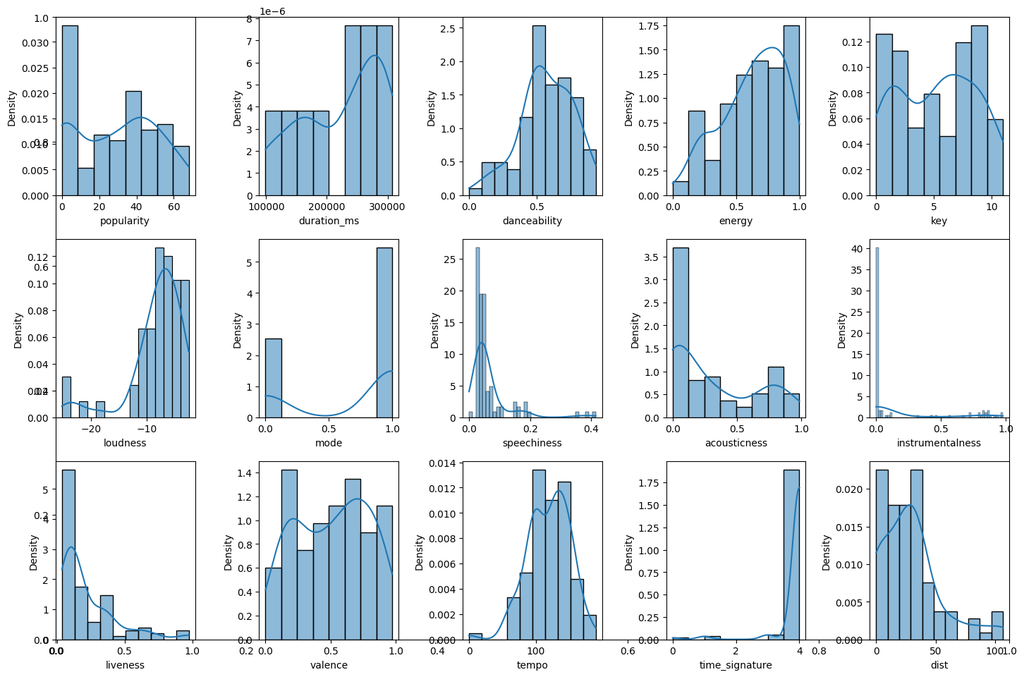

```python
create_distplots_array(results_10_df, dist_cols)
```

### Prediction pairplot against distance

With average of query songs marked by vertical line

query songs averages

```python
results_10_df_avg = results_10_df[results_10_df['is_query'] == 1][dist_cols].mean()
```

```python
results_10_df_avg
```

```
popularity              27.9
duration_ms         222961.9
danceability          0.5575
energy              0.646302
key                      4.9
loudness             -9.1574
mode                     0.7
speechiness            0.055
acousticness        0.248163
instrumentalness    0.205485
liveness             0.28413
valence               0.4576
tempo               108.8655
time_signature           3.6
dist                     0.0
dtype: object
```

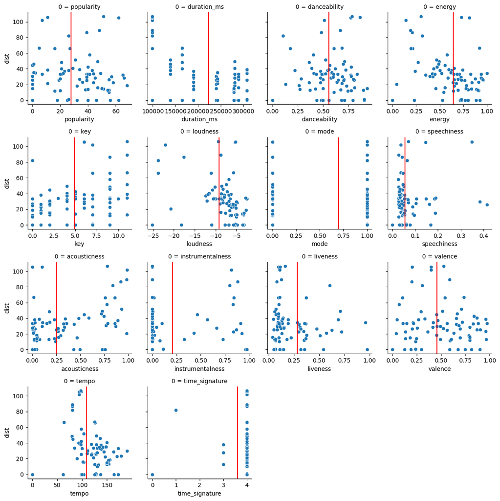

```python
dist_cols_no_dist = [c for c in dist_cols if c != 'dist']
g = sns.FacetGrid(pd.DataFrame(dist_cols_no_dist), col=0, col_wrap=4, sharex=False)
for ax, x_var in zip(g.axes, dist_cols_no_dist):
    sns.scatterplot(data=results_10_df, x=x_var, y='dist', ax=ax)
    ax.axvline(results_10_df_avg[x_var], 0, 100, color='r')
g.tight_layout()
plt.show()
# pp = sns.pairplot(data = results_10_df,
#                   y_vars = ['dist'],
#                   x_vars = )
```

### Distplot for 50 songs similar to ONE song

```python
sample_songs, sample_songs_names, sample_songs_idx = sample_n_songs(df_eng, 10)
sample_onesong_50_idx = sample_songs_idx[0]
results_onesong_50_df = pd.DataFrame()

results_onesong_50_df = query_by_song(sample_onesong_50_idx, df_eng, numerical_cols, 50)
results_onesong_50_df = results_onesong_50_df.reset_index(drop=True)
```

```
Querying:
3052 Something In The Way
idx: 44000, track: Something In The Way, dist: 0.0
idx: 91255, track: Something In The Way, dist: 0.0
idx: 2006, track: Something In The Way, dist: 0.0
idx: 53912, track: Papaoutai, dist: 12.65966003808949
idx: 65502, track: Love Talk - English Version, dist: 13.581592631204927
idx: 21162, track: Diana, dist: 18.16510859644956
idx: 11643, track: Here I Go Again - Radio Mix, dist: 26.009388774673273
idx: 80754, track: Shish Nawata Hoon, dist: 29.894175166577185
idx: 65201, track: Shish Nawata Hoon, dist: 29.894175166577185
idx: 23303, track: Define, dist: 31.798109458547124
idx: 43250, track: Define, dist: 31.798109458547124
idx: 55465, track: Closer X Channa Mereya, dist: 31.878973846094862
idx: 44415, track: Battleships, dist: 36.25786680225411
idx: 97821, track: Leva Minha Timidez, dist: 37.51512912732675
idx: 40898, track: Deus Tremendo (feat. Vanilda Bordieri, Eliane Silva, Lydia Moisés, Suelen de Jesus, Célia Sakamoto, Elaine Martins & Shirley Carvalhaes) - Ao Vivo, dist: 39.38516883240911
idx: 4502, track: Latent Dream, dist: 40.7083328576595
idx: 109379, track: Yeke Yeke - Radio Edit, dist: 41.41257810946452
idx: 107708, track: Anomalie bleue, dist: 41.93407913952564
idx: 80306, track: Yaara, dist: 41.96056920592389
idx: 51350, track: All The Stars (with SZA), dist: 42.2421848895584
idx: 7300, track: Wagon Wheel, dist: 43.581500404185256
idx: 9213, track: Relíquia, dist: 43.99753193680301
idx: 97768, track: Tocando Em Frente, dist: 44.4218024020863
idx: 3217, track: Seven Nation Army, dist: 45.2438406549444
idx: 8003, track: Seven Nation Army, dist: 45.2438406549444
idx: 91514, track: Seven Nation Army, dist: 45.2438406549444
idx: 2057, track: Seven Nation Army, dist: 45.2438406549444
idx: 48438, track: Over Seasons, dist: 45.74653686195385
idx: 51391, track: Moosedrilla (feat. DIVINE), dist: 46.29761118859158
idx: 87999, track: Reproches Al Viento, dist: 46.43020569823854
idx: 100632, track: Over Seasons, dist: 46.66632227701367
idx: 39829, track: Zeit zu leben, dist: 46.88524437780932
idx: 47054, track: Legendary, dist: 47.27663163661267
idx: 2254, track: Legendary, dist: 47.27663163661267
idx: 3456, track: Legendary, dist: 47.27663163661267
idx: 12504, track: 十面埋伏, dist: 47.480314637226236
idx: 70910, track: 十面埋伏, dist: 47.480314637226236
idx: 82172, track: I Still Want You, dist: 50.163481247842455
idx: 100446, track: Salí de Casa, dist: 50.69297550027634
idx: 113696, track: Africa Nossa (with Ismaël Lô), dist: 51.29222489750572
idx: 102922, track: Taare 2.O, dist: 54.35656932165605
idx: 99918, track: Taare 2.O, dist: 54.35656932165605
idx: 36215, track: Imaginary Friend, dist: 54.99607193154799
idx: 7411, track: Pellinore's Ride, dist: 56.26330801579303
idx: 12728, track: 半點心, dist: 56.63581409574202
idx: 88601, track: Is This Love, dist: 56.86671339843723
idx: 12510, track: 十面埋伏, dist: 57.30547874191437
idx: 70918, track: 十面埋伏, dist: 57.30547874191437
idx: 7732, track: Crawdad Hole, dist: 57.50957609483346
idx: 50673, track: Una Oportunidad, dist: 57.886161401811336
```

```python
results_onesong_50_df.to_csv('results_onesong_50.csv')
```

```python
results_onesong = results_onesong_50_df[results_onesong_50_df['is_query'] == 1]
```

```python
results_onesong['dist']
```

```
0    0.0
Name: dist, dtype: float64
```

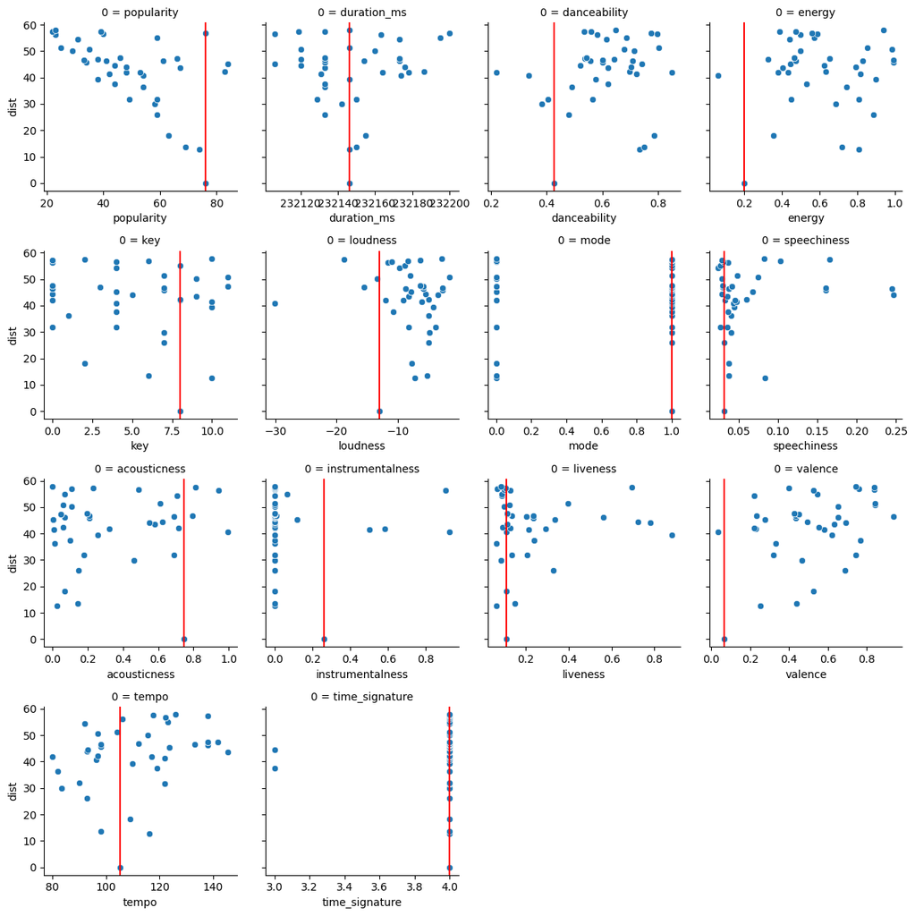

```python
dist_cols_no_dist = [c for c in dist_cols if c != 'dist']
g = sns.FacetGrid(pd.DataFrame(dist_cols_no_dist), col=0, col_wrap=4, sharex=False)
for ax, x_var in zip(g.axes, dist_cols_no_dist):
    sns.scatterplot(data=results_onesong_50_df, x=x_var, y='dist', ax=ax)
    ax.axvline(results_onesong[x_var].values, 0, 100, color='r')
g.tight_layout()
plt.show()
# pp = sns.pairplot(data = results_10_df,
#                   y_vars = ['dist'],
#                   x_vars = )
```

```python
results_onesong
```

|  | track_id | artists | album_name | track_name | popularity | duration_ms | explicit | danceability | energy | key | ... | speechiness | acousticness | instrumentalness | liveness | valence | tempo | time_signature | track_genre | dist | is_query |
| --- | --- | --- | --- | --- | --- | --- | --- | --- | --- | --- | --- | --- | --- | --- | --- | --- | --- | --- | --- | --- | --- |
| 0 | 4gHnSNHs8RyVukKoWdS99f | Nirvana | Nevermind (Remastered) | Something In The Way | 76 | 232146 | 0 | 0.427 | 0.201 | 8 | ... | 0.0317 | 0.745 | 0.263 | 0.109 | 0.0668 | 105.218 | 4 | alternative | 0.0 | 1 |

1 rows × 22 columns

### StandardScaler before querying

```python
from sklearn.preprocessing import StandardScaler, MinMaxScaler
standard_scaler = StandardScaler()
min_max_scaler = MinMaxScaler()

df_eng_scaled = df_eng.copy()

df_eng_scaled[[*numerical_cols]] = standard_scaler.fit_transform(df_eng[[*numerical_cols]])
```

```python
df_eng_scaled.sample(5)
```

|  | track_id | artists | album_name | track_name | popularity | duration_ms | explicit | danceability | energy | key | loudness | mode | speechiness | acousticness | instrumentalness | liveness | valence | tempo | time_signature | track_genre |
| --- | --- | --- | --- | --- | --- | --- | --- | --- | --- | --- | --- | --- | --- | --- | --- | --- | --- | --- | --- | --- |
| 11079 | 1hFAp8hA8QaSCSZtw9MHQy | Richard Harvey | Hans Zimmer: Epic Scores | Kyrie For The Magdalene | -0.728040 | 0.067056 | 0 | -2.188522 | -2.021172 | -0.929534 | -2.918686 | -1.326297 | -0.408128 | 2.027221 | 2.303145 | -0.538689 | -1.693150 | 0.471987 | -6.712656 | british |
| 63379 | 5oZ0VS1ppSqmHywxgfjo4j | PornoGraffitti | WORLDILLIA | Mugen | 0.123792 | 0.246001 | 0 | 0.174018 | 1.234914 | 0.474967 | 0.629894 | -1.326297 | -0.363676 | -0.666144 | -0.504115 | 0.328012 | 1.639027 | -0.908618 | 0.221824 | j-rock |
| 34311 | 7yhvflcXyqw1pQgCSnelZ4 | Raghu Dixit | Antaragni - The Fire Within | Gudugudiya Sedi Nodo | 0.303126 | 0.624237 | 0 | 0.629239 | 0.590853 | -0.929534 | 0.639438 | -1.326297 | -0.340977 | 0.231845 | -0.504101 | -0.730413 | 0.169459 | -0.907717 | 0.221824 | folk |
| 110058 | 5gXKDmafOQ8i4lYr62wxTk | Astrix | He.art | Deep Jungle Walk | 1.110125 | 3.053927 | 0 | 0.295026 | 0.968543 | 0.194067 | -0.017507 | -1.326297 | -0.371242 | -0.945050 | 1.117571 | 0.821768 | -1.423536 | 0.529763 | 0.221824 | trance |
| 113394 | 20ByU9GDZOICvcMQfBWGtj | Hillsong Worship;Brooke Ligertwood | Team Night | Eagle's Wings - Live at Team Night | 0.527292 | -0.298336 | 0 | -0.845908 | -1.528187 | -1.491334 | -0.736489 | 0.753979 | -0.526351 | 1.383652 | -0.504106 | -0.564952 | -1.361822 | -0.998050 | 2.533318 | world-music |

```python
sample_songs, sample_songs_names, sample_songs_idx = sample_n_songs(df_eng_scaled, 10)
sample_onesong_50_idx = sample_songs_idx[0]
results_onesong_50_scaled_df = pd.DataFrame()

results_onesong_50_scaled_df = query_by_song(sample_onesong_50_idx, df_eng_scaled, numerical_cols, 50)
results_onesong_50_scaled_df = results_onesong_50_scaled_df.reset_index(drop=True)

results_onesong_scaled = results_onesong_50_scaled_df[results_onesong_50_scaled_df['is_query'] == 1]
```

```
Querying:
47258 Wild World - 2009 Remastered Version
idx: 71466, track: Wild World - 2009 Remastered Version, dist: 0.0
idx: 39554, track: Sun Goes Down (feat. Jasmine Thompson) - Radio Mix, dist: 0.9227620942180259
idx: 99573, track: Run To You, dist: 0.9882679525501664
idx: 102574, track: Run To You, dist: 0.9882679525501664
idx: 31877, track: I Really Like You, dist: 1.055001240697125
idx: 36179, track: Souvenir, dist: 1.059608231287974
idx: 81204, track: Chauffeur, dist: 1.0710884686295283
idx: 80055, track: Chauffeur, dist: 1.0710884686295283
idx: 65885, track: Moon, dist: 1.1307379390044316
idx: 62150, track: 色香水, dist: 1.1329131112719852
idx: 106509, track: SOS, dist: 1.1506163019552789
idx: 83124, track: Anywhere With You, dist: 1.1515009265854683
idx: 53920, track: Anywhere With You, dist: 1.1515009265854683
idx: 25417, track: Xanadu, dist: 1.156052019739314
idx: 82202, track: Sweetness, dist: 1.1599197842169564
idx: 58119, track: What Do They Know?, dist: 1.1655252272977272
idx: 2902, track: Animal, dist: 1.170725500695594
idx: 97146, track: Pot-Pourri: Chorar por Amor / Amores São Coisas da Vida / Porta Retrato, dist: 1.1813589104291033
idx: 104578, track: Libertad, dist: 1.1878114788020966
idx: 33208, track: Strawberry Huracan, dist: 1.189011632928988
idx: 15323, track: Strawberry Huracan, dist: 1.189011632928988
idx: 94260, track: Strawberry Huracan, dist: 1.189011632928988
idx: 94721, track: SANTA MONICA, dist: 1.1890334864131278
idx: 113243, track: Rescuer (Good News), dist: 1.189604106248235
idx: 104352, track: A Partir De Hoy, dist: 1.1935042547287753
idx: 30671, track: The Nights, dist: 1.2030473230899728
idx: 104537, track: Libertad, dist: 1.2046146943656522
idx: 65343, track: Moon, dist: 1.2050317578969787
idx: 75081, track: Moonlight Shadow, dist: 1.2071986134066692
idx: 94565, track: CAROUSEL, dist: 1.2083727574925978
idx: 30752, track: Feel Good (feat. Daya), dist: 1.2137984173009355
idx: 53803, track: Feel Good (feat. Daya), dist: 1.2137984173009355
idx: 82900, track: The Good Life, dist: 1.2174189485054878
idx: 83437, track: Something Strange, dist: 1.2198123872452886
idx: 8858, track: You're The One, dist: 1.2291735700215074
idx: 15727, track: Adrenaline, dist: 1.2296746031754608
idx: 33467, track: Adrenaline, dist: 1.2296746031754608
idx: 38191, track: This House is a Circus, dist: 1.2380681779024731
idx: 19849, track: Hardanger, dist: 1.2383256925580584
idx: 104272, track: La promesa, dist: 1.2426408971967378
idx: 65604, track: Monster, dist: 1.2445805319138759
idx: 94523, track: Adrenaline, dist: 1.2467197379674948
idx: 17136, track: Marry You, dist: 1.2513589522187616
idx: 110541, track: Learning to Survive, dist: 1.254276827948504
idx: 72117, track: Learning to Survive, dist: 1.254276827948504
idx: 30576, track: Seasons, dist: 1.262351193388812
idx: 47960, track: You Shook Me All Night Long, dist: 1.2686709023868712
idx: 87544, track: Mi Amor Imposible, dist: 1.2689715053487938
idx: 90131, track: Mi Amor Imposible, dist: 1.2689715053487938
idx: 64908, track: Aftermath, dist: 1.270938813798322
```

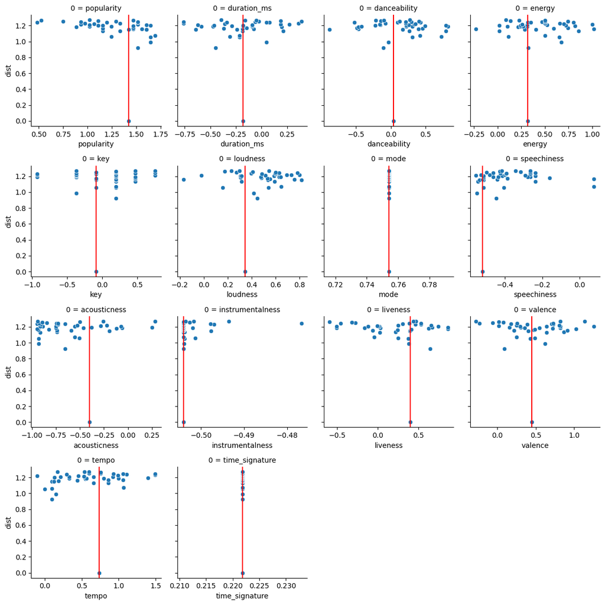

```python
dist_cols_no_dist = [c for c in dist_cols if c != 'dist']
g = sns.FacetGrid(pd.DataFrame(dist_cols_no_dist), col=0, col_wrap=4, sharex=False)
for ax, x_var in zip(g.axes, dist_cols_no_dist):
    sns.scatterplot(data=results_onesong_50_scaled_df, x=x_var, y='dist', ax=ax)
    ax.axvline(results_onesong_scaled[x_var].values, 0, 100, color='r')
g.tight_layout()
plt.show()
```

It seems scaling did not help at all. Quite the opposite in fact, Almost all of the distances are now equally high, instead of seeign some variance. Why could this be? Scaling should not have removed the relations between the factors and their inner variances and directions, yet it seems that some of the original factors with higher ranges did in fact allow for finding more "directed", closer similarity vectors

### Generating song recommendations using Cosine similarity

```python
from sklearn.metrics.pairwise import sigmoid_kernel
from sklearn.metrics.pairwise import cosine_similarity
```

```python
# this function tries to calculate the cosine similiartiy matrix all at once
def generate_recommendation_cosine(song_idx, df, columns, model_type="cosine"):
    """
    """
    if model_type == "cosine":
        # cosine = cosine_similarity(df[columns])
        cosine = sigmoid_kernel(df[columns])
        score = cosine[song_idx]
        similarity_score = sorted(score, key = lambda x:x[1], reverse=True)
        similarity_score = similarity_score[1:11]
        top_songs_index = [i[0] for i in similarity_score]
        return top_songs_index
```

```python
# top_songs_index = generate_recommendation_cosine(25721, df_eng, numerical_cols, "cosine")
```

```python
# cosine-query
# with distances included
def cosineQueryFull(queryPoint, arrCharactPoints, k):
    """
    Calculates the distance of supplied song index
    ---
    Arguments:
        queryPoint - chosen song index from the df_eng dataframe
        arrCharactPoints - index to consider for distance calculation
        k - the number of closest songs to return
    Returns:
        list of tuples of structure [ (song_index, distance), (index, distance), ...] of len k
    """
    query_cosine = queryPoint.to_numpy().reshape(1, -1)
    tmp = arrCharactPoints.copy(deep=True)
    tmp['dist'] = tmp.apply(lambda x: cosine_similarity(query_cosine, x.to_numpy().reshape(1, -1))[0][0], axis=1)
    tmp = tmp.sort_values('dist')
    return_idx = list(tmp.head(k).index)
    return_dist = tmp.head(k)['dist'].values
    return_list = [(index, dist) for index, dist in zip(return_idx, return_dist)]
    return return_list
```

```python
# # Execute k-NN removing the 'query point'
# def querySimilars(df, columns, idx, func, param):
#     """
#     Executes the supplied func query by removing the input song by index (idx),
#     considering only the selected df columns, with param being k or range threshold
#     response = func(queryPoint, arr, param)
#     returns response based on supplied func function
#     """
#     arr = df[columns].copy(deep=True)
#     queryPoint = arr.loc[idx]
#     arr = arr.drop([idx])
#     response = func(queryPoint, arr, param)
#     return response
```

```python
# cosine_results = querySimilars(df_eng, numerical_cols, 25671, cosineQueryFull, 10)
cosine_results =  query_by_song(sample_onesong_50_idx, df_eng, numerical_cols, 50, type='cosine')
```

```
Querying:
47258 Wild World - 2009 Remastered Version
idx: 59775, track: Screams for a Finale! (feat. Leila's Opera Class), dist: 0.9999396594219477
idx: 59306, track: V-7, dist: 0.9999709514392653
idx: 42759, track: Degloved, dist: 0.9999832719635813
idx: 59609, track: Shatter, dist: 0.9999837222183696
idx: 101907, track: Rain Roof, dist: 0.9999858601017227
idx: 14508, track: Chandaa Mama Aao Na, dist: 0.9999864961404938
idx: 42502, track: Martyr, dist: 0.9999885213471665
idx: 82779, track: Eliminación, dist: 0.9999893673621915
idx: 14779, track: She'll Be Coming Round the Mountain, dist: 0.9999897118102018
idx: 26486, track: The Virginia Company (Reprise) - From "Pocahontas"/Soundtrack Version, dist: 0.9999900507761614
idx: 16856, track: Andante in C Major, K. 1a, dist: 0.999990055814353
idx: 26521, track: The Virginia Company (Reprise), dist: 0.9999900683424249
idx: 26780, track: Virginia Company (Reprise), dist: 0.9999901381527475
idx: 39233, track: Carnaval, Op. 9: No. 20, Pause (Live in Japan, 2022), dist: 0.9999901777023655
idx: 16288, track: Carnaval, Op. 9: No. 20, Pause (Live in Japan, 2022), dist: 0.9999901777023655
idx: 16292, track: Carnaval, Op. 9: No. 13, Estrella (Live in Japan, 2022), dist: 0.9999906214953472
idx: 39236, track: Carnaval, Op. 9: No. 13, Estrella (Live in Japan, 2022), dist: 0.9999906214953472
idx: 82927, track: Sin Caras, dist: 0.9999908084376107
idx: 42565, track: Three Day Hold, dist: 0.9999908451026138
idx: 86564, track: Without a Choice, dist: 0.9999909160936422
idx: 48175, track: Without a Choice, dist: 0.9999909160936422
idx: 76588, track: The Escape Of The Doll, dist: 0.9999910357422496
idx: 41594, track: The Escape Of The Doll, dist: 0.9999910357422496
idx: 59967, track: Going Under, dist: 0.999991215045013
idx: 26753, track: W-V 2000 - Instrumental, dist: 0.9999913511921487
idx: 14953, track: Mor, dist: 0.9999915400202742
idx: 98287, track: The Second Goodbye, dist: 0.9999916633434601
idx: 82420, track: Me Robaron, dist: 0.999992084501514
idx: 26464, track: Under the Sea - Reprise, dist: 0.9999922673303114
idx: 82942, track: Cipayos, Traidores y Vendidos, dist: 0.9999924090247034
idx: 66925, track: Backpack, Backpack!, dist: 0.9999925663743381
idx: 42672, track: Beggars Can't Be Choosers, dist: 0.9999925877624413
idx: 52651, track: The Garden Spot Jingle - Show 4, dist: 0.9999926923105961
idx: 110148, track: A State Of Trance (ASOT 1090) - Interview with GXD, Pt. 3, dist: 0.9999927060470671
idx: 83297, track: A State Of Trance (ASOT 1090) - Interview with GXD, Pt. 3, dist: 0.9999927296963372
idx: 14417, track: Baadal Raja, dist: 0.999992815142334
idx: 42848, track: Fuck You up and Get High, dist: 0.9999928186347794
idx: 42846, track: Tickets to the Car Crash (Remix), dist: 0.9999928486198109
idx: 42300, track: New Rochelle, dist: 0.9999928491384364
idx: 98270, track: The Squip Enters, dist: 0.9999928675242719
idx: 110141, track: A State Of Trance (ASOT 1090) - Track Recap, Pt. 2, dist: 0.9999930248852192
idx: 83289, track: A State Of Trance (ASOT 1090) - Track Recap, Pt. 2, dist: 0.9999930529481106
idx: 18152, track: turd whistle, dist: 0.9999931123716554
idx: 66502, track: I Love My Boots, dist: 0.9999931167718664
idx: 42062, track: Shoulders Straight, dist: 0.9999931371927215
idx: 42198, track: Don't Offer Me Weak Drugs or I'll Kick Your Fucking Ass, dist: 0.9999931480231463
idx: 11879, track: Maggie Mae - Remastered 2009, dist: 0.99999328945206
idx: 84670, track: Maggie Mae - Remastered 2009, dist: 0.99999328945206
idx: 54192, track: Tools Use Tools, dist: 0.9999933173440166
idx: 59310, track: The Exorsism Begins..., dist: 0.9999934074678147
```

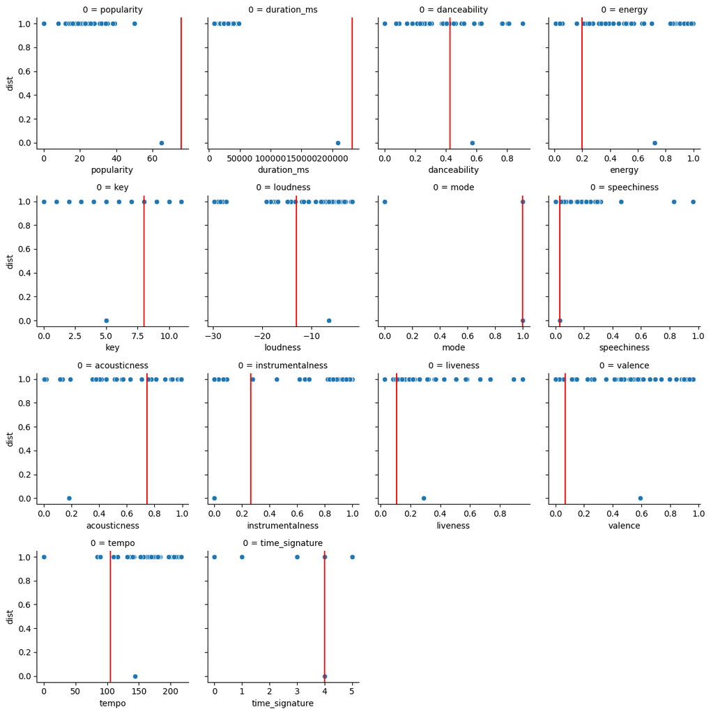

```python
dist_cols_no_dist = [c for c in dist_cols if c != 'dist']
g = sns.FacetGrid(pd.DataFrame(dist_cols_no_dist), col=0, col_wrap=4, sharex=False)
for ax, x_var in zip(g.axes, dist_cols_no_dist):
    sns.scatterplot(data=cosine_results, x=x_var, y='dist', ax=ax)
    ax.axvline(results_onesong[x_var].values, 0, 100, color='r')
g.tight_layout()
plt.show()
```

Perhaps unsurprisingly, the function failed to calculate cosine similarity on unscaled features, which makes sense.

#### Cosine + standard_scaler

```python
cosine_results_scaled =  query_by_song(sample_onesong_50_idx, df_eng_scaled, numerical_cols, 50, type='cosine')
```

```
Querying:
47258 Wild World - 2009 Remastered Version
idx: 59744, track: Outlying, dist: -0.8159739457451968
idx: 59544, track: Outlying, dist: -0.8159739457451968
idx: 59493, track: Outlying, dist: -0.8159739457451968
idx: 111044, track: Roads, dist: -0.8031649323439893
idx: 32094, track: Roads, dist: -0.8031649323439893
idx: 55656, track: Maribou, dist: -0.7877232381410294
idx: 93839, track: Malen'kaja khora, dist: -0.7838940858310062
idx: 3747, track: Yendo De La Cama Al Living, dist: -0.7657007133718614
idx: 67989, track: Yendo De La Cama Al Living, dist: -0.7657007133718614
idx: 86194, track: Yendo De La Cama Al Living, dist: -0.7657007133718614
idx: 85098, track: Yendo De La Cama Al Living, dist: -0.7657007133718614
idx: 2396, track: Yendo De La Cama Al Living, dist: -0.7657007133718614
idx: 99932, track: 深秋的祝褔, dist: -0.7551808932384757
idx: 70046, track: 深秋的祝褔, dist: -0.7551808932384757
idx: 102931, track: 深秋的祝褔, dist: -0.7551808932384757
idx: 65392, track: Tere Pyar Ko Salam O Sanam - Jhankar Beats, dist: -0.7507218703040854
idx: 38030, track: Sculptures Of Anything Goes, dist: -0.7456780574519868
idx: 57792, track: Sculptures Of Anything Goes, dist: -0.7456780574519868
idx: 3884, track: It Don't Matter, dist: -0.7454800504901173
idx: 105480, track: Let It Snow! Let It Snow! Let It Snow!, dist: -0.7436566038063142
idx: 59757, track: Intek, dist: -0.7434506844291712
idx: 55672, track: I am crazy but you like that, dist: -0.7398260544545003
idx: 105721, track: Tides, dist: -0.7386453452036872
idx: 25122, track: Christmas Here With You, dist: -0.7385308286373655
idx: 103529, track: Christmas Here With You, dist: -0.7385308286373655
idx: 37475, track: Christmas Here With You, dist: -0.7385308286373655
idx: 93330, track: Две женщины, dist: -0.7385274573359841
idx: 93379, track: Две женщины, dist: -0.7385274573359841
idx: 54607, track: Quartz, dist: -0.738153927447059
idx: 59687, track: My Favorite Chaharshanbesuri, dist: -0.7376034511846149
idx: 59769, track: InTec_06, dist: -0.7374391504070685
idx: 103679, track: Questions, dist: -0.7364431371518352
idx: 81527, track: Lost Cause, dist: -0.7348930472227109
idx: 31031, track: Lost Cause, dist: -0.7348930472227109
idx: 111844, track: Jeunesse Dorée, dist: -0.7342680600696392
idx: 59537, track: Spiritual Dreams, dist: -0.7338174360989905
idx: 64559, track: Darkjazz Slomo - Instrumental, dist: -0.7330615405055031
idx: 93867, track: Мой костёр, dist: -0.7320409272614264
idx: 106061, track: LOST YOU, dist: -0.7319990774768443
idx: 3458, track: LOST YOU, dist: -0.7319990774768443
idx: 3460, track: LOST YOU, dist: -0.7319990774768443
idx: 103420, track: LOST YOU, dist: -0.7319990774768443
idx: 106065, track: LOST YOU, dist: -0.7319990774768443
idx: 103408, track: LOST YOU, dist: -0.7319990774768443
idx: 93412, track: Мой костер, dist: -0.731046904682104
idx: 93463, track: Мой костер, dist: -0.731046904682104
idx: 105940, track: We Talked Today, dist: -0.7309936864890343
idx: 54255, track: josephine, dist: -0.7303245563876931
idx: 64602, track: Tape Loop - Ronan Remix, dist: -0.7301321374183822
idx: 59158, track: Zeynab, dist: -0.7298278551172225
```

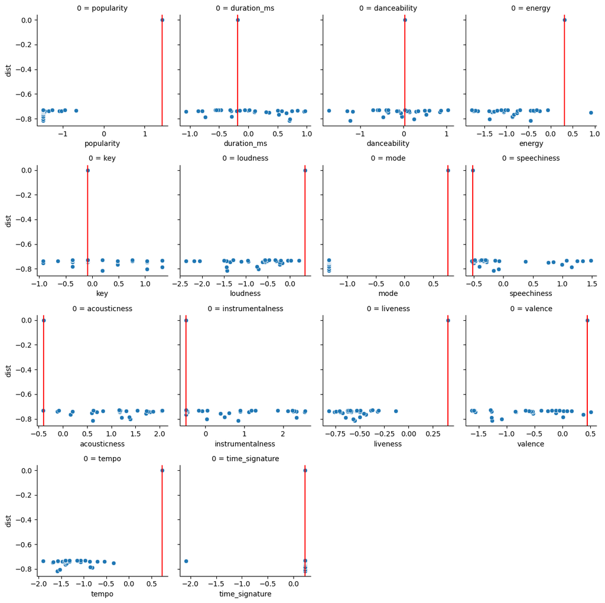

```python
dist_cols_no_dist = [c for c in dist_cols if c != 'dist']
g = sns.FacetGrid(pd.DataFrame(dist_cols_no_dist), col=0, col_wrap=4, sharex=False)
for ax, x_var in zip(g.axes, dist_cols_no_dist):
    sns.scatterplot(data=cosine_results_scaled, x=x_var, y='dist', ax=ax)
    ax.axvline(results_onesong_scaled[x_var].values, 0, 100, color='r')
g.tight_layout()
plt.show()
```

#### Cosine + minmax scaler - stricter

```python
df_eng_scaled[[*numerical_cols]] = min_max_scaler.fit_transform(df_eng[[*numerical_cols]])
```

```python
cosine_results_scaled_minmax =  query_by_song(sample_onesong_50_idx, df_eng_scaled, numerical_cols, 50, type='cosine')
```

```
Querying:
47258 Wild World - 2009 Remastered Version
idx: 101540, track: Box Fan - Loopable With No Fade, dist: 0.23351884209697651
idx: 101888, track: Soothing White Noise - Loopable With No Fade, dist: 0.23426967864005782
idx: 101538, track: White Noise - Loopable With No Fade, dist: 0.25142202585346246
idx: 59310, track: The Exorsism Begins..., dist: 0.2545007911727083
idx: 4379, track: The End of Childhood (feat. Jack Liebeck), dist: 0.2819256722765443
idx: 4131, track: The Departure, dist: 0.30734214143301686
idx: 4664, track: Ferme Les Yeux, dist: 0.30778151965022976
idx: 101342, track: Brown Noise For Sleep 2, dist: 0.344331419142842
idx: 59473, track: Leaving Her Quantum Journey Behind..., dist: 0.3499744535654515
idx: 101375, track: Paradise Rain, dist: 0.3531543764688497
idx: 101921, track: Asmr: Sleepy Box Fan, dist: 0.3566461529435407
idx: 4135, track: dark tree, dist: 0.3574429953534066
idx: 16639, track: dark tree, dist: 0.3574429953534066
idx: 79999, track: "Farewell" Jingle Bells, dist: 0.3597541756390765
idx: 101060, track: Noise for Restless Kids, dist: 0.368631127174497
idx: 101335, track: Pure White Noise, dist: 0.37455852835582604
idx: 101875, track: Hidden Waterfall, dist: 0.3762393423200729
idx: 101723, track: Fan Whir, dist: 0.37644443408176986
idx: 101774, track: Calming Hoover, dist: 0.37700465481709944
idx: 101270, track: Baby White Noise Series - Pure White Noise, dist: 0.37867186936168207
idx: 4247, track: The Departure (Main title theme from "The Leftovers" - Music from the HBO series), dist: 0.37890928946023894
idx: 101566, track: Fan Whir, dist: 0.37939542524090397
idx: 101569, track: Pink Noise Relaxation, dist: 0.38003866579703327
idx: 101967, track: Office Air Conditioners, dist: 0.38422602412042733
idx: 101378, track: Beach Waves and Soothing Brown Noise, dist: 0.3847756936245009
idx: 101361, track: Sleeping Hoover, dist: 0.3865759896247139
idx: 75377, track: Silent Alchemy, dist: 0.3872487288332901
idx: 16121, track: The Seasons, Op. 37a: No. 10, October, Autumn Song, dist: 0.3883699284646693
idx: 59110, track: Farewell, dist: 0.3945295608044934
idx: 16061, track: Piano Sonata No. 14 in C-Sharp Minor, Op. 27 No. 2 "Moonlight": I. Adagio sostenuto, dist: 0.39596903159014746
idx: 16130, track: Piano Sonata No. 14 in C-Sharp Minor, Op. 27 No. 2 "Moonlight": I. Adagio sostenuto, dist: 0.39596903159014746
idx: 39146, track: Piano Sonata No. 14 in C-Sharp Minor, Op. 27 No. 2 "Moonlight": I. Adagio sostenuto, dist: 0.39596903159014746
idx: 101275, track: Brown Noise For Sleep 3, dist: 0.400913348008016
idx: 101898, track: White Noise - BP 940 hz, dist: 0.4019997591804424
idx: 101341, track: Pink Noise For Sleep 14, dist: 0.40512605370907345
idx: 101392, track: White Noise - BP 228 hz, dist: 0.40772236041069293
idx: 93111, track: Три товарища - Remastered, dist: 0.4084292909554567
idx: 101065, track: Neugeborene Schlafhilfe, dist: 0.4113563514271895
idx: 101983, track: Waves From The Ocean, dist: 0.4132461891291479
idx: 101024, track: Dark Depths, dist: 0.4139426526924379
idx: 59599, track: The Mirage, dist: 0.4146424781727078
idx: 59220, track: Flux, dist: 0.4173950083418027
idx: 101083, track: Natur eigene Schlafmaschine, dist: 0.4205922179525618
idx: 101979, track: Brown Noise - Waterfall, dist: 0.42167997327157164
idx: 59040, track: Restless, dist: 0.4221880286961249
idx: 59006, track: Dawn, dist: 0.4241138638863976
idx: 75674, track: Luminescence, dist: 0.4244750958748622
idx: 16188, track: Nutcracker Suite, Op. 71a: Arabian Dance (Coffee), dist: 0.42723846561146284
idx: 101290, track: Wellen Geschwenkt, dist: 0.4313573743990331
idx: 101904, track: Ulayaw, dist: 0.43147466739964213
```

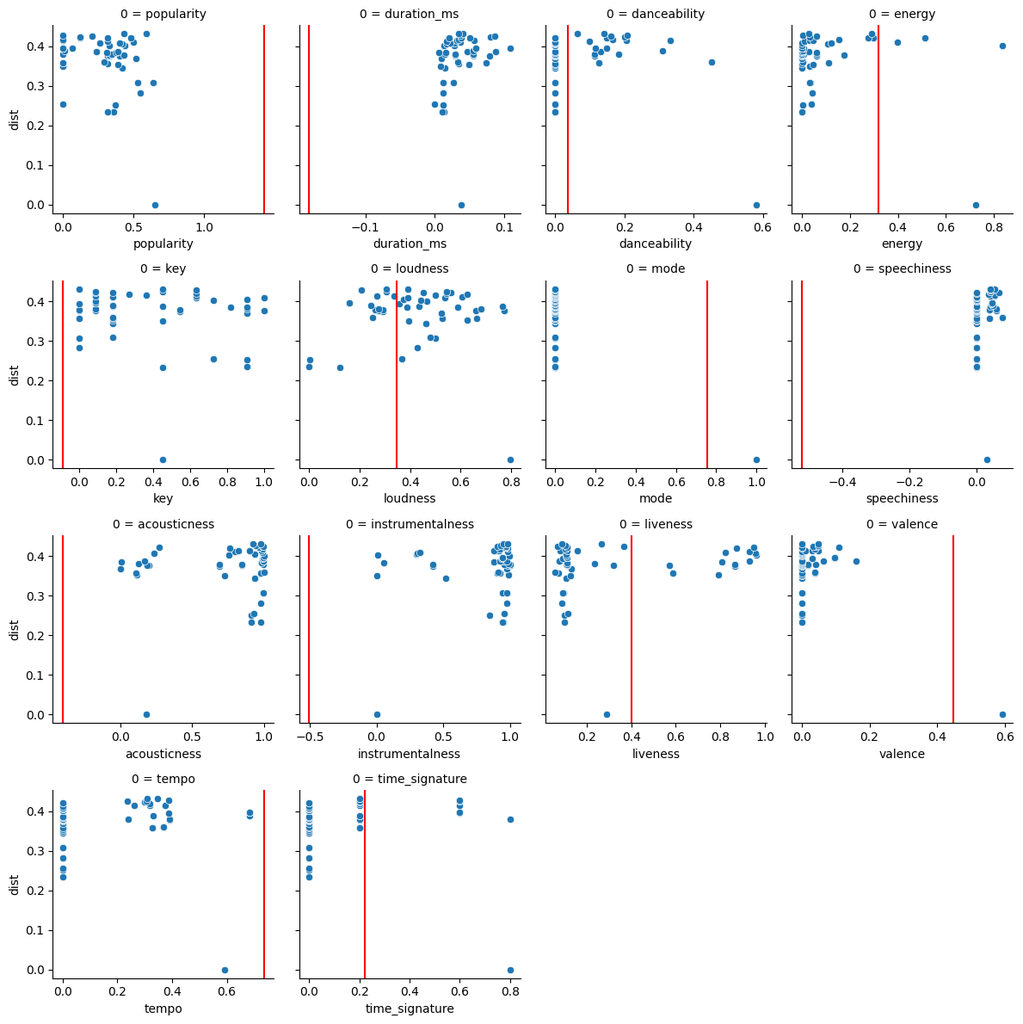

```python
dist_cols_no_dist = [c for c in dist_cols if c != 'dist']
g = sns.FacetGrid(pd.DataFrame(dist_cols_no_dist), col=0, col_wrap=4, sharex=False)
for ax, x_var in zip(g.axes, dist_cols_no_dist):
    sns.scatterplot(data=cosine_results_scaled_minmax, x=x_var, y='dist', ax=ax)
    ax.axvline(results_onesong_scaled[x_var].values, 0, 100, color='r')
g.tight_layout()
plt.show()
```

Definitely working now, still hard to judge the results though, no clear trends of any kind present

### Using text features

For example incorporating track genre info

```python
df_eng.columns
```

```
Index(['track_id', 'artists', 'album_name', 'track_name', 'popularity',
       'duration_ms', 'explicit', 'danceability', 'energy', 'key', 'loudness',
       'mode', 'speechiness', 'acousticness', 'instrumentalness', 'liveness',
       'valence', 'tempo', 'time_signature', 'track_genre'],
      dtype='object')
```

```python
from sklearn.feature_extraction.text import CountVectorizer
song_vectorizer = CountVectorizer()
song_vectorizer.fit(df_eng['track_genre'])
```

```
CountVectorizer()
```

```python
# cosine-query
# with distances included
def cosineQueryWithTextFull(queryPoint, arrCharactPoints, k):
    """
    Calculates the distance of supplied song index
    ---
    Arguments:
        queryPoint - chosen song index from the df_eng dataframe
        arrCharactPoints - index to consider for distance calculation
        k - the number of closest songs to return
    Returns:
        list of tuples of structure [ (song_index, distance), (index, distance), ...] of len k
    """
    text_array1 = song_vectorizer.transform([queryPoint['track_genre']]).toarray()
    num_query_cosine = queryPoint.drop(['track_genre']).to_numpy().reshape(1, -1)
    tmp = arrCharactPoints.copy(deep=True)
    tmp['num_dist'] = tmp.apply(lambda x: cosine_similarity(num_query_cosine,
                                                            pd.DataFrame(x).drop(['track_genre']).
                                                            to_numpy().reshape(1, -1))[0][0], axis=1)
    tmp['text_dist'] = tmp.apply(lambda x: cosine_similarity(text_array1,
                                                             song_vectorizer.transform([x['track_genre']])
                                                             .toarray())[0][0], axis=1)
    tmp['dist'] = tmp['num_dist'] + tmp['text_dist']
    tmp = tmp.sort_values('dist')
    return_idx = list(tmp.head(k).index)
    return_dist = tmp.head(k)['dist'].values
    return_list = [(index, dist) for index, dist in zip(return_idx, return_dist)]
    return return_list
```

```python
# # Execute k-NN removing the 'query point'
# def querySimilarsWithText(df, columns, idx, func, param):
#     """
#     Executes the supplied func query by removing the input song by index (idx),
#     considering only the selected df columns, with param being k or range threshold
#     response = func(queryPoint, arr, param)
#     returns response based on supplied func function
#     """
#     arr = df[columns].copy(deep=True)
#     queryPoint = arr.loc[idx]
#     arr = arr.drop([idx])
#     response = func(queryPoint, arr, param)
#     return response
```

```python
numerical_cols_genre = [*numerical_cols, 'track_genre']
```

```python
numerical_cols_genre
```

```
['popularity',
 'duration_ms',
 'danceability',
 'energy',
 'key',
 'loudness',
 'mode',
 'speechiness',
 'acousticness',
 'instrumentalness',
 'liveness',
 'valence',
 'tempo',
 'time_signature',
 'track_genre']
```

```python
cosine_results_scaled_minmax_text =  query_by_song(sample_onesong_50_idx, df_eng_scaled, numerical_cols_genre, 50, type='cosine_text')
```

```
Querying:
47258 Wild World - 2009 Remastered Version
idx: 101540, track: Box Fan - Loopable With No Fade, dist: 0.23351884209697651
idx: 101888, track: Soothing White Noise - Loopable With No Fade, dist: 0.23426967864005782
idx: 101538, track: White Noise - Loopable With No Fade, dist: 0.25142202585346246
idx: 59310, track: The Exorsism Begins..., dist: 0.2545007911727083
idx: 4379, track: The End of Childhood (feat. Jack Liebeck), dist: 0.2819256722765443
idx: 4131, track: The Departure, dist: 0.30734214143301686
idx: 4664, track: Ferme Les Yeux, dist: 0.30778151965022976
idx: 101342, track: Brown Noise For Sleep 2, dist: 0.344331419142842
idx: 59473, track: Leaving Her Quantum Journey Behind..., dist: 0.3499744535654515
idx: 101375, track: Paradise Rain, dist: 0.3531543764688497
idx: 101921, track: Asmr: Sleepy Box Fan, dist: 0.3566461529435407
idx: 16639, track: dark tree, dist: 0.3574429953534066
idx: 4135, track: dark tree, dist: 0.3574429953534066
idx: 79999, track: "Farewell" Jingle Bells, dist: 0.3597541756390765
idx: 101060, track: Noise for Restless Kids, dist: 0.368631127174497
idx: 101335, track: Pure White Noise, dist: 0.37455852835582604
idx: 101875, track: Hidden Waterfall, dist: 0.3762393423200729
idx: 101723, track: Fan Whir, dist: 0.37644443408176986
idx: 101774, track: Calming Hoover, dist: 0.37700465481709944
idx: 101270, track: Baby White Noise Series - Pure White Noise, dist: 0.37867186936168207
idx: 4247, track: The Departure (Main title theme from "The Leftovers" - Music from the HBO series), dist: 0.37890928946023894
idx: 101566, track: Fan Whir, dist: 0.37939542524090397
idx: 101569, track: Pink Noise Relaxation, dist: 0.38003866579703327
idx: 101967, track: Office Air Conditioners, dist: 0.38422602412042733
idx: 101378, track: Beach Waves and Soothing Brown Noise, dist: 0.3847756936245009
idx: 101361, track: Sleeping Hoover, dist: 0.3865759896247139
idx: 75377, track: Silent Alchemy, dist: 0.3872487288332901
idx: 16121, track: The Seasons, Op. 37a: No. 10, October, Autumn Song, dist: 0.3883699284646693
idx: 59110, track: Farewell, dist: 0.3945295608044934
idx: 16061, track: Piano Sonata No. 14 in C-Sharp Minor, Op. 27 No. 2 "Moonlight": I. Adagio sostenuto, dist: 0.39596903159014746
idx: 16130, track: Piano Sonata No. 14 in C-Sharp Minor, Op. 27 No. 2 "Moonlight": I. Adagio sostenuto, dist: 0.39596903159014746
idx: 39146, track: Piano Sonata No. 14 in C-Sharp Minor, Op. 27 No. 2 "Moonlight": I. Adagio sostenuto, dist: 0.39596903159014746
idx: 101275, track: Brown Noise For Sleep 3, dist: 0.400913348008016
idx: 101898, track: White Noise - BP 940 hz, dist: 0.4019997591804424
idx: 101341, track: Pink Noise For Sleep 14, dist: 0.40512605370907345
idx: 101392, track: White Noise - BP 228 hz, dist: 0.40772236041069293
idx: 93111, track: Три товарища - Remastered, dist: 0.4084292909554567
idx: 101065, track: Neugeborene Schlafhilfe, dist: 0.4113563514271895
idx: 101983, track: Waves From The Ocean, dist: 0.4132461891291479
idx: 101024, track: Dark Depths, dist: 0.4139426526924379
idx: 59599, track: The Mirage, dist: 0.4146424781727078
idx: 59220, track: Flux, dist: 0.4173950083418027
idx: 101083, track: Natur eigene Schlafmaschine, dist: 0.4205922179525618
idx: 101979, track: Brown Noise - Waterfall, dist: 0.42167997327157164
idx: 59040, track: Restless, dist: 0.4221880286961249
idx: 59006, track: Dawn, dist: 0.4241138638863976
idx: 75674, track: Luminescence, dist: 0.4244750958748622
idx: 16188, track: Nutcracker Suite, Op. 71a: Arabian Dance (Coffee), dist: 0.42723846561146284
idx: 101290, track: Wellen Geschwenkt, dist: 0.4313573743990331
idx: 101904, track: Ulayaw, dist: 0.43147466739964213
```

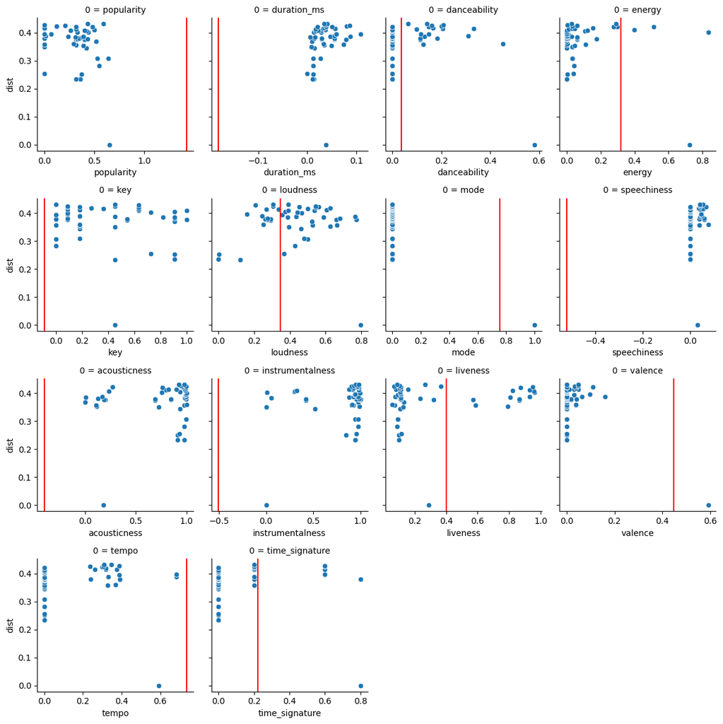

```python
dist_cols_no_dist = [c for c in dist_cols if c != 'dist']
# dist_cols_no_dist = [*dist_cols_no_dist, 'num_dist', 'text_dist']
g = sns.FacetGrid(pd.DataFrame(dist_cols_no_dist), col=0, col_wrap=4, sharex=False)
for ax, x_var in zip(g.axes, dist_cols_no_dist):
    sns.scatterplot(data=cosine_results_scaled_minmax_text, x=x_var, y='dist', ax=ax)
    ax.axvline(results_onesong_scaled[x_var].values, 0, 100, color='r')
g.tight_layout()
plt.show()
```

No noticeable improvement unfortunately

```python
numerical_cols_reduced = [
 'danceability',
 'energy',
 # 'key',
 'loudness',
 'mode',
 'speechiness',
 'acousticness',
 'instrumentalness',
 'liveness',
 'valence',
 'tempo'
]
```

```python
results_onesong_50_reduced = query_by_song(sample_onesong_50_idx, df_eng, numerical_cols_reduced, 50)
# results_onesong_50_df = results_onesong_50_df.reset_index(drop=True)
```

```
Querying:
47258 Wild World - 2009 Remastered Version
idx: 71466, track: Wild World - 2009 Remastered Version, dist: 0.0
idx: 12543, track: 該如何放棄愛, dist: 0.28614277904570473
idx: 113226, track: Never Have I Ever - Studio, dist: 0.3050906422688166
idx: 100106, track: Y Qué, dist: 0.3320523452710416
idx: 107667, track: Another Broken Heart, dist: 0.34104084830583964
idx: 33631, track: Never Meant, dist: 0.3988847608019122
idx: 18448, track: Gump (Parody of "Lump" by The Presidents of the United States), dist: 0.40498595889749545
idx: 106340, track: Come Give Me Love, dist: 0.40850458993749417
idx: 34571, track: Parasiva, dist: 0.4635778575385185
idx: 19846, track: Never Comin' Home, dist: 0.468124182242274
idx: 95155, track: Rumbarengue, dist: 0.47426491542175125
idx: 104417, track: Estoy Hecho De Pedacitos De Ti, dist: 0.48616145466295263
idx: 104170, track: Como Si Fueras a Morir Mañana, dist: 0.4875686142482969
idx: 12835, track: 及時行樂, dist: 0.49141880305906005
idx: 109931, track: Elysium (I Go Crazy), dist: 0.4945561646567557
idx: 18098, track: Not That Kind of Thing, dist: 0.5060301275615947
idx: 113004, track: Way Maker - Single Version, dist: 0.5082405139301717
idx: 2466, track: Way Maker - Single Version, dist: 0.5082405139301717
idx: 3711, track: Way Maker - Single Version, dist: 0.5082405139301717
idx: 28497, track: Da Minha Vida (Quem Sabe Sou Eu), dist: 0.5103706986103337
idx: 113444, track: I Believe - Live, dist: 0.519872379951472
idx: 4694, track: I Believe - Live, dist: 0.519872379951472
idx: 40937, track: Eu Nasci de Novo - Ao Vivo, dist: 0.5225884518433229
idx: 76605, track: Libertà, dist: 0.5298451096604045
idx: 35560, track: Moça Bonita, dist: 0.5311649555576875
idx: 842, track: Protest Songs, dist: 0.5397703215257326
idx: 77912, track: Traição, dist: 0.5398893960803492
idx: 58112, track: Every Day Is Exactly The Same, dist: 0.543159184769993
idx: 66750, track: The Freeze Dance, dist: 0.5458238418015537
idx: 12313, track: 黃金時代, dist: 0.5459551263611301
idx: 70665, track: 黃金時代, dist: 0.5459551263611301
idx: 40678, track: Chegou o Avivamento, dist: 0.5496998180825611
idx: 67929, track: Quiero Tenerte, dist: 0.5558935149828609
idx: 36942, track: 4 millions, dist: 0.5687075258865529
idx: 113719, track: All In All, dist: 0.5725609487207493
idx: 80957, track: Sadka, dist: 0.5726055282443617
idx: 12707, track: 粵語殘片, dist: 0.5777411963846747
idx: 50195, track: Pagando por tu actitud, dist: 0.5854373206415847
idx: 3525, track: Dancing Queen, dist: 0.5898088195339262
idx: 3522, track: Dancing Queen, dist: 0.5898088195339262
idx: 3517, track: Dancing Queen, dist: 0.5898088195339262
idx: 3516, track: Dancing Queen, dist: 0.5898088195339262
idx: 99248, track: Everything, dist: 0.5901376276635888
idx: 102245, track: Everything, dist: 0.5901376276635888
idx: 66674, track: N.O., dist: 0.590177303867234
idx: 100809, track: Rejected, dist: 0.5979663786277281
idx: 33460, track: witchblades, dist: 0.5994683728104483
idx: 64074, track: Christmas Calling (Jolly Jones), dist: 0.6029759145513177
idx: 62068, track: Christmas Calling (Jolly Jones), dist: 0.6029759145513177
idx: 62072, track: Christmas Calling (Jolly Jones), dist: 0.6029759145513177
```

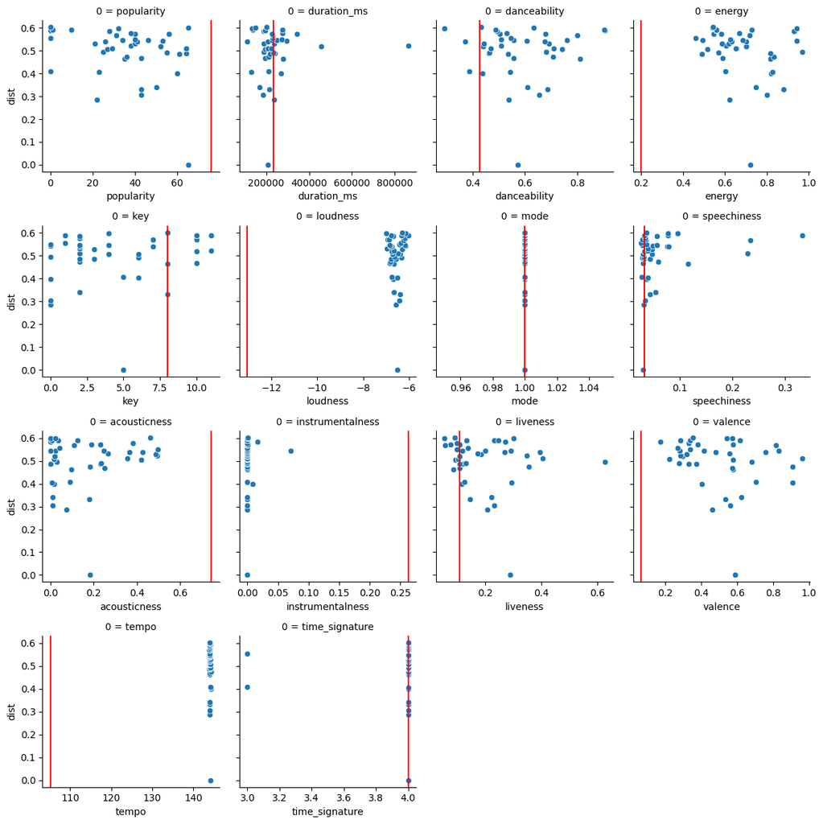

```python
dist_cols_no_dist = [c for c in dist_cols if c != 'dist']
g = sns.FacetGrid(pd.DataFrame(dist_cols_no_dist), col=0, col_wrap=4, sharex=False)
for ax, x_var in zip(g.axes, dist_cols_no_dist):
    sns.scatterplot(data=results_onesong_50_reduced, x=x_var, y='dist', ax=ax)
    ax.axvline(results_onesong[x_var].values, 0, 100, color='r')
g.tight_layout()
plt.show()
```

No real improvements noticed

### TODO: Visualize relations between song parameters, group by genre itd

### TODO: Classify for genre etc

## Additional song data exploration

### Grouping by genre

```python
df_genre = df_eng[['track_genre', *numerical_cols]].groupby(['track_genre'], as_index=False).mean()
```

```python
df_genre.head()
```

|  | track_genre | popularity | duration_ms | danceability | energy | key | loudness | mode | speechiness | acousticness | instrumentalness | liveness | valence | tempo | time_signature |
| --- | --- | --- | --- | --- | --- | --- | --- | --- | --- | --- | --- | --- | --- | --- | --- |
| 0 | acoustic | 42.483 | 214896.957 | 0.549593 | 0.435368 | 5.045 | -9.447843 | 0.816 | 0.043247 | 0.566816 | 0.038336 | 0.153244 | 0.424023 | 119.010624 | 3.885 |
| 1 | afrobeat | 24.399 | 248412.791 | 0.669580 | 0.702812 | 5.551 | -7.789353 | 0.511 | 0.086579 | 0.270860 | 0.253483 | 0.184596 | 0.698619 | 119.213337 | 3.946 |
| 2 | alt-rock | 33.943 | 235455.907 | 0.534493 | 0.754173 | 5.738 | -6.191489 | 0.641 | 0.055071 | 0.122162 | 0.054097 | 0.210249 | 0.518260 | 124.634404 | 3.939 |
| 3 | alternative | 24.337 | 222016.180 | 0.559927 | 0.720030 | 5.567 | -6.078777 | 0.606 | 0.070101 | 0.147820 | 0.038159 | 0.201376 | 0.495570 | 122.232394 | 3.942 |
| 4 | ambient | 44.191 | 237059.038 | 0.367867 | 0.237162 | 4.945 | -18.601365 | 0.620 | 0.041562 | 0.776790 | 0.676221 | 0.129283 | 0.167498 | 111.113129 | 3.653 |

```python
df_genre['track_genre'].nunique()
```

```
114
```

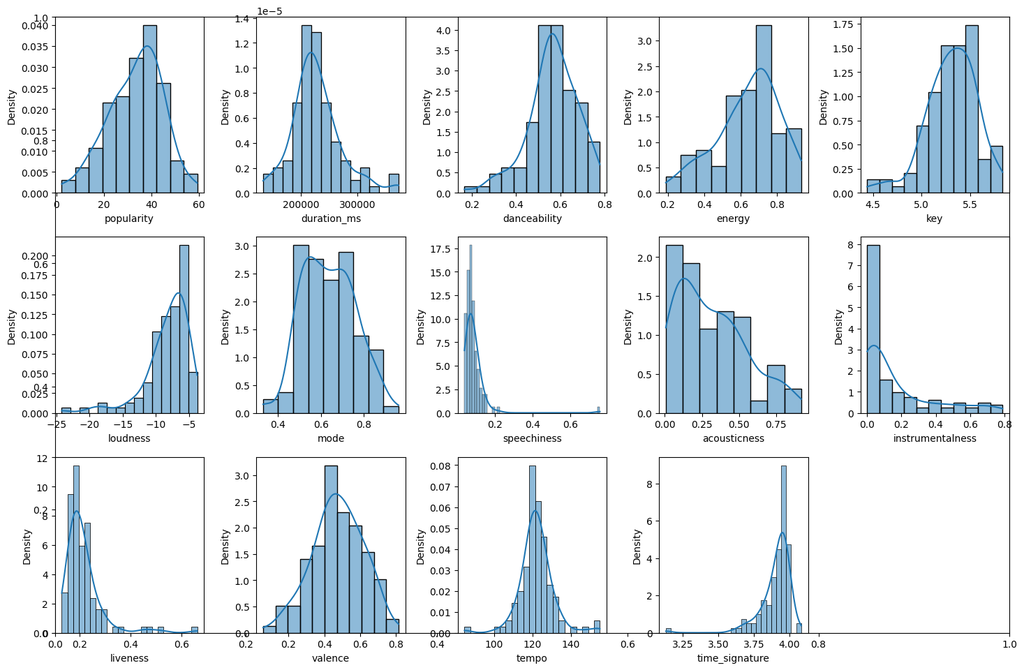

```python
create_distplots_array(df_genre, numerical_cols)
```

#### Let's check out some genres

```python
df_genre['track_genre'].sample(5)
```

```
78         party
104      spanish
49     hardstyle
76         opera
10     breakbeat
Name: track_genre, dtype: object
```

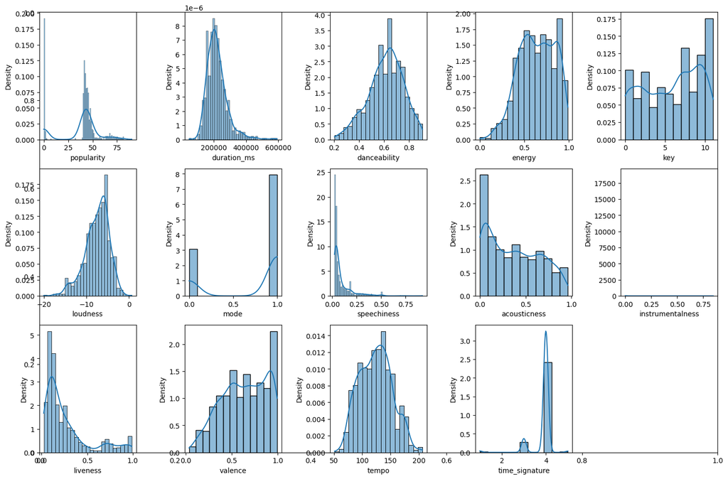

```python
create_distplots_array(df_eng[df_eng['track_genre'] == 'r-n-b'], numerical_cols)
```

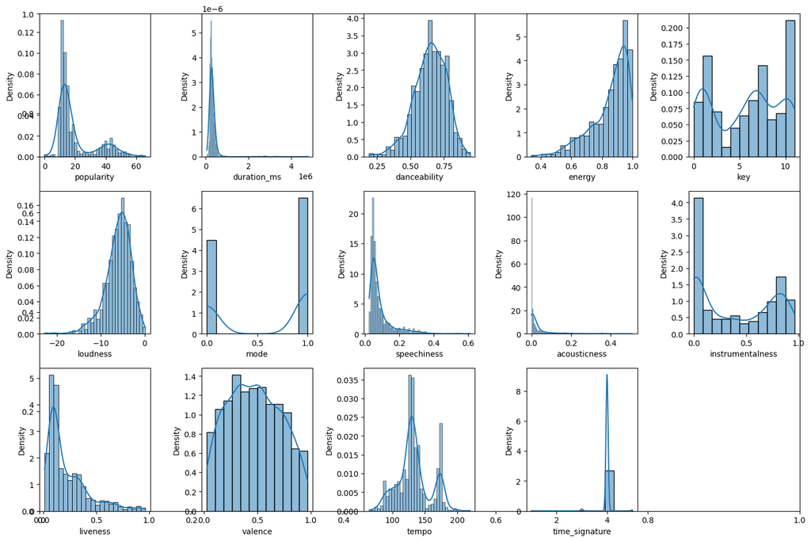

```python
create_distplots_array(df_eng[df_eng['track_genre'] == 'breakbeat'], numerical_cols)
```

```python
def create_distplots_array_multiple(df, columns, hue):
    # for df in dataframes:
        # columns_len = len(columns)
        # plt_rows = math.ceil((len(columns) + 1) // 5)
        # plt.subplots(figsize = (plt_rows*5,10))

        # for i, col in enumerate(columns):
        #     plt.subplot(plt_rows,5, i+1)
        #     sns.histplot(df[col], kde=True, stat="density")
        #     # sns.histplot(df_eng[col], kde=True)
        # plt.tight_layout()
    # g = sns.FacetGrid(pd.DataFrame(df), col=0, col_wrap=4, sharex=False)
    # for ax, x_var in zip(g.axes, dist_cols_no_dist):
    #     sns.scatterplot(data=results_10_df, x=x_var, y='dist', ax=ax)
    #     ax.axvline(results_10_df_avg[x_var], 0, 100, color='r')
    # g.tight_layout()
    # plt.show()
    pass
```

```python
df_rnb = df_eng[df_eng['track_genre'] == 'r-n-b'][['track_genre', *numerical_cols]]
df_spanish = df_eng[df_eng['track_genre'] == 'spanish'][['track_genre', *numerical_cols]]
df_breakbeat = df_eng[df_eng['track_genre'] == 'breakbeat'][['track_genre', *numerical_cols]]
df_3_genres = pd.concat([df_rnb, df_spanish, df_breakbeat])
```

```python
df_3_genres
```

|  | track_genre | popularity | duration_ms | danceability | energy | key | loudness | mode | speechiness | acousticness | instrumentalness | liveness | valence | tempo | time_signature |
| --- | --- | --- | --- | --- | --- | --- | --- | --- | --- | --- | --- | --- | --- | --- | --- |
| 87000 | r-n-b | 81 | 205458 | 0.907 | 0.393 | 4 | -7.636 | 0 | 0.0539 | 0.451000 | 0.000001 | 0.1350 | 0.202 | 104.949 | 4 |
| 87001 | r-n-b | 76 | 162453 | 0.857 | 0.427 | 8 | -8.638 | 1 | 0.1120 | 0.281000 | 0.000000 | 0.1080 | 0.366 | 130.033 | 4 |
| 87002 | r-n-b | 80 | 180055 | 0.650 | 0.306 | 9 | -9.443 | 1 | 0.0393 | 0.570000 | 0.000007 | 0.0707 | 0.605 | 118.068 | 4 |
| 87003 | r-n-b | 69 | 154733 | 0.547 | 0.335 | 4 | -9.200 | 0 | 0.0307 | 0.747000 | 0.000000 | 0.1010 | 0.474 | 115.838 | 3 |
| 87004 | r-n-b | 90 | 298933 | 0.629 | 0.547 | 10 | -13.123 | 0 | 0.0550 | 0.720000 | 0.003140 | 0.0604 | 0.197 | 108.375 | 4 |
| ... | ... | ... | ... | ... | ... | ... | ... | ... | ... | ... | ... | ... | ... | ... | ... |
| 10995 | breakbeat | 11 | 240400 | 0.624 | 0.972 | 11 | -5.689 | 0 | 0.0677 | 0.007890 | 0.319000 | 0.4430 | 0.502 | 125.445 | 4 |
| 10996 | breakbeat | 10 | 273230 | 0.718 | 0.946 | 7 | -4.516 | 1 | 0.0686 | 0.001950 | 0.000001 | 0.0564 | 0.596 | 130.002 | 4 |
| 10997 | breakbeat | 10 | 244114 | 0.734 | 0.896 | 2 | -3.572 | 1 | 0.0412 | 0.004060 | 0.084300 | 0.0574 | 0.407 | 87.502 | 4 |
| 10998 | breakbeat | 10 | 2287542 | 0.598 | 0.940 | 10 | -2.479 | 0 | 0.0562 | 0.001100 | 0.000707 | 0.3420 | 0.473 | 175.013 | 4 |
| 10999 | breakbeat | 12 | 700290 | 0.648 | 0.739 | 8 | -11.031 | 1 | 0.0292 | 0.000156 | 0.891000 | 0.1060 | 0.754 | 125.554 | 4 |

3000 rows × 15 columns

```python
df_3_genres_melt = df_3_genres.melt(['track_genre'], var_name='cols', value_name='vals')
```

```python
# g = sns.FacetGrid(df_3_genres_melt, col='cols', hue='track_genre', palette = 'Set1')
# g = (g.map(sns.distplot, "vals", hist=True, rug=False))
```

```python
# create_distplots_array_multiple([df_rnb, df_spanish, df_breakbeat], numerical_cols)
```

## Genre classification

Reutilizing our uniform classification function from Project 1.

```python
def preprocess_and_train_classification(model, dataset, target_col, standard_scale = True, model_name=None):

    print(f'model {model_name} started training')

    X = dataset.drop([target_col], axis=1)
    y = dataset[[target_col]]
    X_train, X_valid, y_train, y_valid = train_test_split(X, y, shuffle=True, train_size=0.8)

    # Preprocessing transformers
    numerical_transformer = StandardScaler()

    numerical_cols = [cname for cname in X_train.columns if X_train[cname].dtype in ['int64', 'float64', 'UInt32', 'int32']]

    # combined preprocessor
    preprocessor = ColumnTransformer(
        transformers = [
            ('num', numerical_transformer, numerical_cols),
            # ('cat', categorical_transformer, categorical_cols)
        ]
    )

    if standard_scale:
        # Bundle preprocessing and modeling code in a pipeline
        train_pipeline = Pipeline(steps=[
            ('preprocessor', preprocessor),
            ('model', model)
        ])
    else:
        train_pipeline = Pipeline(steps=[
            ('model', model)
        ])

    # Preprocessing of training data, fit model
    train_pipeline.fit(X_train, y_train)

    # Preprocessing of validation data, get predictions
    preds = train_pipeline.predict(X_valid)

    acc = accuracy_score(y_valid, preds)
    f1 = f1_score(y_valid, preds, average=None, labels=model.classes_)
    cm = confusion_matrix(y_valid, preds, labels=model.classes_)
    labels = model.classes_

    print(f'model {model_name} trained, acc: {acc}')

    return acc, f1, cm, labels, model, preds, X_valid, y_valid, train_pipeline, dataset
```

```python
def model_results_to_dataframe(acc, f1, cm, model_name, results_df):
    new_row = {
        'model': model_name,
        'acc': acc,
        'cm': cm,
        'f1': f1,
        # 'score': score,
        # 'score_by_max': round(score * 100 / max_sales,2),
        # 'score_by_min': round(score * 100 / min_sales,2),
        # 'score_by_mean': round(score * 100 / avg_sales,2),
        # 'score_by_median': round(score * 100 / median_sales,2),
        # 'score_by_std': round(score * 100 / std_sales,2)
    }
    new_df = pd.DataFrame([new_row])
    results_df = pd.concat([results_df, new_df], ignore_index=True)

    return results_df
```

```python
def display_confusion_matrix(cm, labels):
    disp = ConfusionMatrixDisplay(confusion_matrix = cm,
                             display_labels=labels
                             )
    disp_plot = disp.plot()
    plt.show()
```

```python
numerical_cols_genre = [*numerical_cols, 'track_genre']
numerical_cols_genre_reduced = [*numerical_cols_reduced, 'track_genre']
```

```python
df_eng_numerical = df_eng[numerical_cols_genre]
df_eng_numerical_reduced = df_eng[numerical_cols_genre_reduced]
datasets = [df_eng_numerical, df_eng_numerical_reduced]
dataset_names = ['numerical', 'numerical_reduced']
```

```python
# classification
from sklearn.svm import SVC
from sklearn.metrics  import (f1_score,accuracy_score, confusion_matrix,
classification_report, ConfusionMatrixDisplay)
from sklearn.ensemble import AdaBoostClassifier, RandomForestClassifier
from sklearn.neighbors import KNeighborsClassifier
from sklearn.tree import DecisionTreeClassifier
from xgboost.sklearn import XGBClassifier
```

```python
c_random_forest_model = RandomForestClassifier()
svc_model = SVC()
knc_model = KNeighborsClassifier()
c_tree_model = DecisionTreeClassifier()
# xgb_c_model = XGBClassifier()
# models = [c_random_forest_model, svc_model, knc_model, c_tree_model, xgb_c_model]
# model_names = ['random_forest', 'svc', 'kneighbors', 'tree', 'xgb']
models = [c_random_forest_model, svc_model, knc_model, c_tree_model]
model_names = ['random_forest', 'svc', 'kneighbors', 'tree']
```

### Warning - long running code below

```python
# classification_results_df = pd.DataFrame()
# acc_best = 0
# best_model = None
# best_dataset = None
# for d_index, dataset in enumerate(datasets):
#     for m_index, model in enumerate(models):
#         for to_scale in [True, False]:
#             model_name = f'{model_names[m_index]}_{dataset_names[d_index]}'
#             if to_scale:
#                 model_name += '_scaled'
#             else:
#                 model_name += '_not_scaled'

#             # reset the models
#             c_random_forest_model = RandomForestClassifier()
#             svc_model = SVC()
#             knc_model = KNeighborsClassifier()
#             c_tree_model = DecisionTreeClassifier()
#             # xgb_c_model = XGBClassifier()

#             acc, f1, cm, labels, model, preds, X_valid, y_valid, result_model, used_dataset = preprocess_and_train_classification(
#                                             model = model,
#                                             dataset = dataset,
#                                             target_col = 'track_genre',
#                                             standard_scale=to_scale,
#                                             model_name = model_name
#                                            )

#             classification_results_df = model_results_to_dataframe(acc, f1, cm,
#                                                                    model_name,
#                                                                    classification_results_df)

#             if acc > acc_best:
#                 best_model = result_model
#                 best_dataset = used_dataset
```

```python
classification_results_df.sort_values(by='acc', ascending=False)
```

|  | model | acc | cm | f1 |
| --- | --- | --- | --- | --- |
| 0 | random_forest_numerical_scaled | 0.322237 | [[45, 0, 0, 0, 2, 0, 0, 8, 2, 1, 0, 4, 0, 0, 3... | [0.22959183673469388, 0.36548223350253806, 0.0... |
| 1 | random_forest_numerical_not_scaled | 0.322061 | [[54, 0, 0, 0, 2, 2, 0, 2, 2, 0, 0, 1, 6, 0, 7... | [0.2482758620689655, 0.42857142857142855, 0.02... |
| 2 | svc_numerical_scaled | 0.276053 | [[40, 0, 1, 0, 3, 1, 0, 2, 0, 0, 0, 0, 5, 1, 4... | [0.17094017094017094, 0.254957507082153, 0.042... |
| 7 | tree_numerical_not_scaled | 0.214868 | [[22, 2, 1, 0, 5, 4, 0, 2, 1, 1, 0, 8, 3, 1, 2... | [0.11, 0.15041782729805014, 0.0240549828178694... |
| 6 | tree_numerical_scaled | 0.212149 | [[21, 0, 3, 1, 7, 0, 0, 2, 2, 2, 0, 6, 7, 0, 3... | [0.09905660377358491, 0.195, 0.036974789915966... |
| 4 | kneighbors_numerical_scaled | 0.197982 | [[54, 1, 3, 0, 4, 4, 1, 9, 5, 3, 0, 3, 8, 0, 1... | [0.12646370023419204, 0.15863141524105753, 0.0... |
| 5 | kneighbors_numerical_not_scaled | 0.062632 | [[16, 6, 7, 0, 6, 4, 4, 10, 5, 6, 5, 3, 7, 4, ... | [0.0328879753340185, 0.04501607717041801, 0.03... |
| 3 | svc_numerical_not_scaled | 0.029737 | [[0, 0, 0, 0, 0, 0, 0, 0, 0, 0, 0, 0, 0, 2, 0,... | [0.0, 0.0, 0.0, 0.0, 0.0, 0.0, 0.0, 0.0, 0.0, ... |

```python
classification_results_df.to_csv('genre_classification_results.csv')
```

```python
import pickle
best_model_pickle = pickle.dumps(best_model)
```

#### Testing the best performing model on a random sample

```python
test_sample = best_dataset.sample(frac=0.2)
X = test_sample.drop(['track_genre'], axis=1)
y = test_sample[['track_genre']]
# X_train, X_test, y_train, y_test = train_test_split(X, y, shuffle=True, train_size=0.8)
```

```python
test_sample['predicted_genre'] = best_model.predict(X)
test_sample['correct'] = test_sample['track_genre'] == test_sample['predicted_genre']
```

```python
test_sample.dtypes
```

```
popularity            int64
duration_ms           int64
danceability        float64
energy              float64
key                   int64
loudness            float64
mode                  int64
speechiness         float64
acousticness        float64
instrumentalness    float64
liveness            float64
valence             float64
tempo               float64
time_signature        int64
track_genre          object
predicted_genre      object
correct                bool
dtype: object
```

```python
test_sample['correct'] = test_sample['correct'].astype('int')
```

```python
test_sample_by_genre = test_sample.drop(['predicted_genre'], axis=1).groupby('track_genre', as_index=False).mean()
```

```python
test_sample_by_genre
```

|  | track_genre | popularity | duration_ms | danceability | energy | key | loudness | mode | speechiness | acousticness | instrumentalness | liveness | valence | tempo | time_signature | correct |
| --- | --- | --- | --- | --- | --- | --- | --- | --- | --- | --- | --- | --- | --- | --- | --- | --- |
| 0 | acoustic | 42.140000 | 207727.915000 | 0.556950 | 0.445173 | 5.185000 | -9.317655 | 0.810000 | 0.042759 | 0.554525 | 0.030310 | 0.163908 | 0.437343 | 117.117865 | 3.900000 | 0.830000 |
| 1 | afrobeat | 23.161290 | 240836.064516 | 0.647333 | 0.716435 | 5.903226 | -7.688559 | 0.500000 | 0.099693 | 0.268364 | 0.257403 | 0.188459 | 0.697871 | 122.115043 | 3.908602 | 0.822581 |
| 2 | alt-rock | 36.263393 | 235463.276786 | 0.534304 | 0.756277 | 5.660714 | -6.405473 | 0.598214 | 0.058033 | 0.111332 | 0.066810 | 0.242039 | 0.513296 | 121.637893 | 3.950893 | 0.709821 |
| 3 | alternative | 21.523316 | 222289.409326 | 0.538751 | 0.712902 | 5.523316 | -6.073596 | 0.590674 | 0.076626 | 0.164461 | 0.029170 | 0.198002 | 0.476609 | 124.460404 | 3.917098 | 0.461140 |
| 4 | ambient | 44.944444 | 228217.156566 | 0.371558 | 0.220336 | 4.797980 | -19.299217 | 0.590909 | 0.044116 | 0.797634 | 0.706300 | 0.130825 | 0.171777 | 108.571551 | 3.727273 | 0.787879 |
| ... | ... | ... | ... | ... | ... | ... | ... | ... | ... | ... | ... | ... | ... | ... | ... | ... |
| 109 | techno | 39.830000 | 317662.775000 | 0.677675 | 0.755070 | 5.465000 | -8.088155 | 0.530000 | 0.060835 | 0.077649 | 0.556754 | 0.155285 | 0.332783 | 128.651110 | 3.975000 | 0.450000 |
| 110 | trance | 39.209184 | 272586.586735 | 0.595102 | 0.840291 | 5.882653 | -6.432219 | 0.464286 | 0.076105 | 0.031614 | 0.408560 | 0.237703 | 0.285995 | 133.259041 | 3.969388 | 0.724490 |
| 111 | trip-hop | 33.253589 | 270068.622010 | 0.623952 | 0.604995 | 5.368421 | -9.493608 | 0.502392 | 0.083000 | 0.215341 | 0.345123 | 0.217650 | 0.455625 | 116.728928 | 3.918660 | 0.741627 |
| 112 | turkish | 39.969849 | 219237.768844 | 0.606236 | 0.623349 | 5.522613 | -8.221563 | 0.381910 | 0.116285 | 0.328002 | 0.031948 | 0.166666 | 0.472188 | 122.779467 | 3.944724 | 0.804020 |
| 113 | world-music | 42.597938 | 299585.082474 | 0.415778 | 0.501615 | 5.304124 | -9.429361 | 0.891753 | 0.040569 | 0.348442 | 0.070617 | 0.235298 | 0.249346 | 121.616124 | 3.824742 | 0.773196 |

114 rows × 16 columns

```python
# test_sample_by_genre['acc'] = test_sample_by_genre.groupby(level=0).apply(
#     lambda x:
# )
```

```python
top_genres = test_sample_by_genre.sort_values(['correct'], ascending=False).head(10)
bot_genres = test_sample_by_genre.sort_values(['correct'], ascending=False).tail(10)
```

```python
top_genres
```

|  | track_genre | popularity | duration_ms | danceability | energy | key | loudness | mode | speechiness | acousticness | instrumentalness | liveness | valence | tempo | time_signature | correct |
| --- | --- | --- | --- | --- | --- | --- | --- | --- | --- | --- | --- | --- | --- | --- | --- | --- |
| 42 | grindcore | 14.817734 | 128624.290640 | 0.267405 | 0.924744 | 5.004926 | -6.390773 | 0.650246 | 0.141455 | 0.002744 | 0.534111 | 0.298476 | 0.226622 | 118.452044 | 3.798030 | 0.955665 |
| 18 | comedy | 24.826347 | 215079.772455 | 0.579725 | 0.712497 | 5.053892 | -10.361689 | 0.754491 | 0.764113 | 0.717512 | 0.003033 | 0.667500 | 0.444046 | 99.819910 | 3.604790 | 0.952096 |
| 52 | honky-tonk | 16.194444 | 165439.494444 | 0.573394 | 0.385739 | 4.944444 | -11.298056 | 0.966667 | 0.037776 | 0.699947 | 0.033569 | 0.189150 | 0.649967 | 117.832417 | 3.833333 | 0.944444 |
| 93 | romance | 2.809302 | 192995.730233 | 0.425586 | 0.300779 | 5.548837 | -13.195726 | 0.330233 | 0.063335 | 0.865498 | 0.068387 | 0.224553 | 0.396147 | 109.960833 | 3.697674 | 0.939535 |
| 101 | sleep | 37.691489 | 203400.813830 | 0.163284 | 0.315490 | 5.047872 | -24.650404 | 0.691489 | 0.056820 | 0.647709 | 0.773273 | 0.353910 | 0.053785 | 84.606686 | 3.148936 | 0.930851 |
| 75 | new-age | 28.729064 | 304286.339901 | 0.355056 | 0.219097 | 4.985222 | -18.458212 | 0.684729 | 0.053932 | 0.824566 | 0.718108 | 0.193039 | 0.174210 | 106.793714 | 3.714286 | 0.926108 |
| 66 | kids | 14.328502 | 163271.256039 | 0.777894 | 0.605986 | 5.212560 | -8.110029 | 0.724638 | 0.161906 | 0.254002 | 0.015529 | 0.161842 | 0.671720 | 120.762589 | 3.985507 | 0.908213 |
| 54 | idm | 15.147059 | 265807.416667 | 0.534922 | 0.577335 | 5.348039 | -12.222853 | 0.563725 | 0.077058 | 0.350589 | 0.688430 | 0.170172 | 0.328014 | 122.864255 | 3.857843 | 0.901961 |
| 105 | study | 24.688119 | 146243.698020 | 0.693416 | 0.405816 | 5.430693 | -10.831173 | 0.430693 | 0.097384 | 0.557559 | 0.785346 | 0.163320 | 0.407260 | 114.729614 | 3.945545 | 0.900990 |
| 35 | forro | 41.566327 | 190225.637755 | 0.648740 | 0.788842 | 5.270408 | -5.142566 | 0.688776 | 0.055377 | 0.386419 | 0.000380 | 0.278265 | 0.762934 | 145.250546 | 4.000000 | 0.897959 |

```python
bot_genres
```

|  | track_genre | popularity | duration_ms | danceability | energy | key | loudness | mode | speechiness | acousticness | instrumentalness | liveness | valence | tempo | time_signature | correct |
| --- | --- | --- | --- | --- | --- | --- | --- | --- | --- | --- | --- | --- | --- | --- | --- | --- |
| 86 | punk-rock | 40.927184 | 211831.038835 | 0.500053 | 0.811786 | 5.563107 | -5.883801 | 0.689320 | 0.064357 | 0.080094 | 0.035726 | 0.214791 | 0.590107 | 133.223728 | 3.951456 | 0.407767 |
| 90 | rock | 17.979592 | 220295.938776 | 0.538122 | 0.694041 | 5.617347 | -6.429520 | 0.714286 | 0.047713 | 0.179220 | 0.013088 | 0.189146 | 0.532262 | 127.339184 | 3.923469 | 0.382653 |
| 68 | latino | 28.192308 | 209141.927885 | 0.759072 | 0.728139 | 5.235577 | -5.139293 | 0.528846 | 0.123664 | 0.169312 | 0.010841 | 0.174847 | 0.614223 | 119.130404 | 3.971154 | 0.379808 |
| 29 | dubstep | 42.062893 | 230247.037736 | 0.501283 | 0.749277 | 5.289308 | -5.297176 | 0.534591 | 0.085543 | 0.127564 | 0.107729 | 0.184515 | 0.254035 | 131.974962 | 3.968553 | 0.352201 |
| 88 | reggae | 21.238636 | 214448.471591 | 0.739341 | 0.745642 | 5.636364 | -5.039585 | 0.562500 | 0.121727 | 0.163233 | 0.002658 | 0.187185 | 0.641466 | 120.955682 | 4.000000 | 0.312500 |
| 57 | indie-pop | 43.155251 | 209092.000000 | 0.603110 | 0.546352 | 5.378995 | -8.386580 | 0.799087 | 0.068405 | 0.385954 | 0.034589 | 0.166495 | 0.467268 | 118.943986 | 3.913242 | 0.292237 |
| 71 | metal | 42.794444 | 257110.211111 | 0.460067 | 0.841583 | 5.405556 | -5.270217 | 0.627778 | 0.072419 | 0.033489 | 0.068549 | 0.199645 | 0.419596 | 127.324072 | 3.961111 | 0.277778 |
| 53 | house | 36.142105 | 192445.063158 | 0.665500 | 0.764684 | 5.463158 | -5.149332 | 0.531579 | 0.066007 | 0.108500 | 0.033271 | 0.195181 | 0.511789 | 121.483926 | 3.978947 | 0.221053 |
| 102 | songwriter | 35.553846 | 218390.641026 | 0.561144 | 0.440739 | 4.979487 | -9.542374 | 0.835897 | 0.056971 | 0.539981 | 0.018606 | 0.145730 | 0.416876 | 119.229369 | 3.820513 | 0.148718 |
| 89 | reggaeton | 22.675127 | 212968.106599 | 0.758061 | 0.744822 | 5.360406 | -4.966558 | 0.553299 | 0.117263 | 0.153995 | 0.002216 | 0.165678 | 0.631096 | 117.420142 | 3.994924 | 0.116751 |